```python
# AIPin E-Commerce Project
# Eidtor: Ruoxin Wang
# 08/06/2023
```

```python
import numpy as np
import pandas as pd
import matplotlib.pyplot as plt
%matplotlib inline

import datetime as dt
import seaborn as sns
sns.set(color_codes=True)
pd.set_option('display.max_columns', None)

import warnings
warnings.filterwarnings("ignore")

import statsmodels.api as sm
from scipy import stats
from scipy.stats.mstats import zscore

import plotly.express as px
from sklearn.datasets import make_swiss_roll
from mpl_toolkits.mplot3d import Axes3D
from sklearn.preprocessing import StandardScaler
from sklearn.cluster import KMeans
```

# Part 1: Import Dataset

```python
# Customers Dataset
customers = pd.read_csv('/Users/rwang0104/Desktop/AIPin/ecommerce/customers.csv')
customers.info()
customers['id']=customers['id'].astype(object)
customers.info()
customers.head()
```

```
<class 'pandas.core.frame.DataFrame'>
RangeIndex: 44661 entries, 0 to 44660
Data columns (total 3 columns):
 #   Column      Non-Null Count  Dtype
---  ------      --------------  -----
 0   id          44661 non-null  int64
 1   full_name   33699 non-null  object
 2   created_at  44661 non-null  object
dtypes: int64(1), object(2)
memory usage: 1.0+ MB
<class 'pandas.core.frame.DataFrame'>
RangeIndex: 44661 entries, 0 to 44660
Data columns (total 3 columns):
 #   Column      Non-Null Count  Dtype
---  ------      --------------  -----
 0   id          44661 non-null  object
 1   full_name   33699 non-null  object
 2   created_at  44661 non-null  object
dtypes: object(3)
memory usage: 1.0+ MB
```

|  | id | full_name | created_at |
| --- | --- | --- | --- |
| 0 | 8652230815 | NaN | 2016-08-16 |
| 1 | 8686141151 | Warren Perez | 2016-08-22 |
| 2 | 8686909727 | Micheal Robles | 2016-08-22 |
| 3 | 8686915935 | Michael Ellis | 2016-08-22 |
| 4 | 8686918303 | Robert Stewart | 2016-08-22 |

full_name has null value

```python
# Orders_items Dataset
orders_items = pd.read_csv('/Users/rwang0104/Desktop/AIPin/ecommerce/orders_items.csv')
orders_items.info()
orders_items['id']=orders_items['id'].astype(object)
orders_items['order_id']=orders_items['order_id'].astype(object)
orders_items['product_id']=orders_items['product_id'].astype(object)
orders_items['variant_id']=orders_items['variant_id'].astype(object)
orders_items.info()
orders_items.head()
```

```
<class 'pandas.core.frame.DataFrame'>
RangeIndex: 36826 entries, 0 to 36825
Data columns (total 10 columns):
 #   Column              Non-Null Count  Dtype
---  ------              --------------  -----
 0   id                  36826 non-null  int64
 1   order_id            36826 non-null  int64
 2   product_id          36802 non-null  float64
 3   product_style       36826 non-null  object
 4   variant_id          36826 non-null  int64
 5   sku                 36826 non-null  object
 6   product_title       36826 non-null  object
 7   fulfillment_status  35257 non-null  object
 8   price               36826 non-null  float64
 9   quantity            36826 non-null  int64
dtypes: float64(2), int64(4), object(4)
memory usage: 2.8+ MB
<class 'pandas.core.frame.DataFrame'>
RangeIndex: 36826 entries, 0 to 36825
Data columns (total 10 columns):
 #   Column              Non-Null Count  Dtype
---  ------              --------------  -----
 0   id                  36826 non-null  object
 1   order_id            36826 non-null  object
 2   product_id          36802 non-null  object
 3   product_style       36826 non-null  object
 4   variant_id          36826 non-null  object
 5   sku                 36826 non-null  object
 6   product_title       36826 non-null  object
 7   fulfillment_status  35257 non-null  object
 8   price               36826 non-null  float64
 9   quantity            36826 non-null  int64
dtypes: float64(1), int64(1), object(8)
memory usage: 2.8+ MB
```

|  | id | order_id | product_id | product_style | variant_id | sku | product_title | fulfillment_status | price | quantity |
| --- | --- | --- | --- | --- | --- | --- | --- | --- | --- | --- |
| 0 | 13325125855 | 7675398239 | 12927629215.0 | 2c259a42d38f5f097274beff811168e2 | 50547057311 | 000d96b3b77b33af530eec77689bd210 | 5cfd6c4e00b25e6dec5538928206b7b8 | NaN | 35.0 | 1 |
| 1 | 13327045983 | 7676331935 | 12927632095.0 | dd804c4025d230467823200aa82e9219 | 50547118303 | e26c77e84b91c9939c23c3e3ef66475a | 0e6e45ad42707e9732119f4b98aec7ce | NaN | 79.0 | 1 |
| 2 | 13327109727 | 7676363167 | 12928055775.0 | f4e2e3c5433e4120889e2a7e0e0180a8 | 50553858975 | 0be0c8bf78ecf36416a40c9012acd19e | bede8c8f4e3c9c9d9a061d9a8d086cdc | NaN | 58.0 | 1 |
| 3 | 13327495903 | 7676539359 | 12927625695.0 | 08ba660ec5643520a73108bef6f3ddd6 | 50547001887 | 0503dec809a8a2600d9acc5249900ecb | 27d598cb953eff3667f7d051fe795284 | fulfilled | 25.0 | 1 |
| 4 | 13327518751 | 7676549855 | 12927690655.0 | 68ac90e5df73ae9b662174b21dc1586f | 50548035807 | 38de0d087208588510907b5c2d149e4b | 07dd8ba2ccadf3f3766750f10f6d05b5 | fulfilled | 25.0 | 1 |

```python
orders_items = orders_items.rename(columns={'id':'orders_items_id'})
```

product_id, fulfillment_status have null value

```python
# Orders Dataset
orders = pd.read_csv('/Users/rwang0104/Desktop/AIPin/ecommerce/orders.csv')
orders.info()
orders['id']=orders['id'].astype(object)
orders['customer_id']=orders['customer_id'].astype(object)
orders.info()
orders.head()
```

```
<class 'pandas.core.frame.DataFrame'>
RangeIndex: 21358 entries, 0 to 21357
Data columns (total 13 columns):
 #   Column                  Non-Null Count  Dtype
---  ------                  --------------  -----
 0   id                      21358 non-null  int64
 1   created_at              21358 non-null  object
 2   closed_at               20195 non-null  object
 3   cancelled_at            410 non-null    object
 4   customer_id             21358 non-null  int64
 5   financial_status        21358 non-null  object
 6   fulfillment_status      20680 non-null  object
 7   processed_at            21358 non-null  object
 8   total_price             21358 non-null  float64
 9   shipping_rate           21358 non-null  float64
 10  subtotal_price          21358 non-null  float64
 11  total_discounts         21358 non-null  float64
 12  total_line_items_price  21358 non-null  float64
dtypes: float64(5), int64(2), object(6)
memory usage: 2.1+ MB
<class 'pandas.core.frame.DataFrame'>
RangeIndex: 21358 entries, 0 to 21357
Data columns (total 13 columns):
 #   Column                  Non-Null Count  Dtype
---  ------                  --------------  -----
 0   id                      21358 non-null  object
 1   created_at              21358 non-null  object
 2   closed_at               20195 non-null  object
 3   cancelled_at            410 non-null    object
 4   customer_id             21358 non-null  object
 5   financial_status        21358 non-null  object
 6   fulfillment_status      20680 non-null  object
 7   processed_at            21358 non-null  object
 8   total_price             21358 non-null  float64
 9   shipping_rate           21358 non-null  float64
 10  subtotal_price          21358 non-null  float64
 11  total_discounts         21358 non-null  float64
 12  total_line_items_price  21358 non-null  float64
dtypes: float64(5), object(8)
memory usage: 2.1+ MB
```

|  | id | created_at | closed_at | cancelled_at | customer_id | financial_status | fulfillment_status | processed_at | total_price | shipping_rate | subtotal_price | total_discounts | total_line_items_price |
| --- | --- | --- | --- | --- | --- | --- | --- | --- | --- | --- | --- | --- | --- |
| 0 | 7675398239 | 2016-08-21 | 2016-08-25 | 2016-08-22 | 8683754719 | voided | NaN | 2016-08-21 | 44.57 | 6.33 | 35.0 | 0.0 | 35.0 |
| 1 | 7676331935 | 2016-08-22 | 2016-08-22 | NaN | 8686224991 | refunded | NaN | 2016-08-22 | 124.55 | 0.00 | 114.0 | 0.0 | 114.0 |
| 2 | 7676363167 | 2016-08-22 | NaN | 2016-08-22 | 8686224991 | voided | NaN | 2016-08-22 | 97.68 | 7.00 | 83.0 | 0.0 | 83.0 |
| 3 | 7676539359 | 2016-08-22 | 2016-08-22 | NaN | 8686915935 | paid | fulfilled | 2016-08-22 | 131.10 | 0.00 | 120.0 | 0.0 | 120.0 |
| 4 | 7676549855 | 2016-08-22 | 2016-08-22 | NaN | 8686924319 | paid | fulfilled | 2016-08-22 | 91.12 | 7.00 | 77.0 | 0.0 | 77.0 |

```python
# Fulfillment has 3 status and fulfilled should be the one that be focused on
orders.fulfillment_status.value_counts()
```

```
fulfilled    20369
partial        309
restocked        2
Name: fulfillment_status, dtype: int64
```

```python
orders = orders.rename(columns={"id": "order_id", 'created_at':'order_created_at','closed_at':'order_closed_at'})
```

closed_at, cancelled_at, fulfillment_status have null value

```python
# Products_skus Dataset
products_skus = pd.read_csv('/Users/rwang0104/Desktop/AIPin/ecommerce/products_skus.csv')
products_skus.info()
products_skus['id']=products_skus['id'].astype(object)
products_skus['product_id']=products_skus['product_id'].astype(object)
products_skus.info()
products_skus.head()
```

```
<class 'pandas.core.frame.DataFrame'>
RangeIndex: 1356 entries, 0 to 1355
Data columns (total 6 columns):
 #   Column         Non-Null Count  Dtype
---  ------         --------------  -----
 0   id             1356 non-null   int64
 1   product_id     1356 non-null   int64
 2   product_style  1356 non-null   object
 3   sku            1356 non-null   object
 4   created_at     1356 non-null   object
 5   price          1356 non-null   float64
dtypes: float64(1), int64(2), object(3)
memory usage: 63.7+ KB
<class 'pandas.core.frame.DataFrame'>
RangeIndex: 1356 entries, 0 to 1355
Data columns (total 6 columns):
 #   Column         Non-Null Count  Dtype
---  ------         --------------  -----
 0   id             1356 non-null   object
 1   product_id     1356 non-null   object
 2   product_style  1356 non-null   object
 3   sku            1356 non-null   object
 4   created_at     1356 non-null   object
 5   price          1356 non-null   float64
dtypes: float64(1), object(5)
memory usage: 63.7+ KB
```

|  | id | product_id | product_style | sku | created_at | price |
| --- | --- | --- | --- | --- | --- | --- |
| 0 | 50547147871 | 12927633311 | d510a563d66df17daf05e72a6af123b7 | 0ecbe4277237cb1207b31815166d37b9 | 2016-08-18 | 29.0 |
| 1 | 50547117727 | 12927632095 | dd804c4025d230467823200aa82e9219 | f8e9bf1495c45676e8822e7ad4c97a93 | 2016-08-18 | 39.5 |
| 2 | 4886503364093 | 375446050301 | 8f61ed9720d09c9303fbc0b3184d478d | ccf2a80ad99d9dc449fbd5a904210d2c | 2016-11-14 | 24.0 |
| 3 | 50547000415 | 12927625695 | 08ba660ec5643520a73108bef6f3ddd6 | db1ea83c6299a2df5e39e420223fbd81 | 2016-08-18 | 25.0 |
| 4 | 50547135135 | 12927632799 | 6056dc7fb0e6987bfb6d08a8a707446f | c4f9cdb1df7a9add57df53e34290cbeb | 2016-08-18 | 31.5 |

No null value

```python
# Products Dataset
products = pd.read_csv('/Users/rwang0104/Desktop/AIPin/ecommerce/products.csv')
products.info()
products['id']=products['id'].astype(object)
products.info()
products.head()
```

```
<class 'pandas.core.frame.DataFrame'>
RangeIndex: 247 entries, 0 to 246
Data columns (total 5 columns):
 #   Column        Non-Null Count  Dtype
---  ------        --------------  -----
 0   id            247 non-null    int64
 1   title         247 non-null    object
 2   product_type  242 non-null    object
 3   created_at    247 non-null    object
 4   published_at  223 non-null    object
dtypes: int64(1), object(4)
memory usage: 9.8+ KB
<class 'pandas.core.frame.DataFrame'>
RangeIndex: 247 entries, 0 to 246
Data columns (total 5 columns):
 #   Column        Non-Null Count  Dtype
---  ------        --------------  -----
 0   id            247 non-null    object
 1   title         247 non-null    object
 2   product_type  242 non-null    object
 3   created_at    247 non-null    object
 4   published_at  223 non-null    object
dtypes: object(5)
memory usage: 9.8+ KB
```

|  | id | title | product_type | created_at | published_at |
| --- | --- | --- | --- | --- | --- |
| 0 | 12927633311 | 6d1eeb39ae340f8d01d93779f80595ed | Dress | 2016-08-18 | 2016-08-18 |
| 1 | 12927632095 | 0e6e45ad42707e9732119f4b98aec7ce | Bomber | 2016-08-18 | 2016-08-18 |
| 2 | 12927625695 | 27d598cb953eff3667f7d051fe795284 | Shirts | 2016-08-18 | 2018-02-05 |
| 3 | 12928059103 | fb337868ffefe5e008e8dc6d6a4f283a | Blazer | 2016-08-18 | 2016-08-18 |
| 4 | 12927632799 | d57bc87aca919b4758da6974cdf607fa | Hooide | 2016-08-18 | NaN |

```python
products = products.rename(columns={'id': 'product_id', 'created_at':'product_create_at','published_at':'product_published_at'})
```

product_type, published_at have null value

```python
# Traffic Dataset
traffic = pd.read_csv('/Users/rwang0104/Desktop/AIPin/ecommerce/traffic.csv')
traffic.info()
traffic.head()
```

```
<class 'pandas.core.frame.DataFrame'>
RangeIndex: 579 entries, 0 to 578
Data columns (total 8 columns):
 #   Column                 Non-Null Count  Dtype
---  ------                 --------------  -----
 0   index                  579 non-null    int64
 1   date_day               579 non-null    object
 2   page_views             579 non-null    int64
 3   sessions               579 non-null    int64
 4   product_detail_views   579 non-null    int64
 5   product_checkouts      579 non-null    int64
 6   product_adds_to_carts  579 non-null    int64
 7   avg_session_in_s       579 non-null    float64
dtypes: float64(1), int64(6), object(1)
memory usage: 36.3+ KB
```

|  | index | date_day | page_views | sessions | product_detail_views | product_checkouts | product_adds_to_carts | avg_session_in_s |
| --- | --- | --- | --- | --- | --- | --- | --- | --- |
| 0 | 0 | 2016-08-17 | 204 | 6 | 0 | 0 | 0 | 2374.166667 |
| 1 | 1 | 2016-08-18 | 661 | 27 | 0 | 0 | 0 | 1632.111111 |
| 2 | 2 | 2016-08-19 | 241 | 12 | 0 | 0 | 0 | 1891.250000 |
| 3 | 3 | 2016-08-20 | 534 | 23 | 0 | 0 | 0 | 1557.956522 |
| 4 | 4 | 2016-08-21 | 10276 | 4946 | 0 | 0 | 0 | 73.470481 |

No null value

```python
# Transactions Dataset
transactions = pd.read_csv('/Users/rwang0104/Desktop/AIPin/ecommerce/transactions.csv')
transactions.info()
transactions['order_id']=transactions['order_id'].astype(object)
transactions['id']=transactions['id'].astype(object)
transactions['parent_id']=transactions['parent_id'].astype(object)
transactions.info()
transactions.head()
```

```
<class 'pandas.core.frame.DataFrame'>
RangeIndex: 27563 entries, 0 to 27562
Data columns (total 8 columns):
 #   Column      Non-Null Count  Dtype
---  ------      --------------  -----
 0   order_id    27563 non-null  int64
 1   id          27563 non-null  int64
 2   parent_id   4877 non-null   float64
 3   amount      27563 non-null  float64
 4   error_code  1643 non-null   object
 5   kind        27563 non-null  object
 6   status      27563 non-null  object
 7   created_at  27563 non-null  object
dtypes: float64(2), int64(2), object(4)
memory usage: 1.7+ MB
<class 'pandas.core.frame.DataFrame'>
RangeIndex: 27563 entries, 0 to 27562
Data columns (total 8 columns):
 #   Column      Non-Null Count  Dtype
---  ------      --------------  -----
 0   order_id    27563 non-null  object
 1   id          27563 non-null  object
 2   parent_id   4877 non-null   object
 3   amount      27563 non-null  float64
 4   error_code  1643 non-null   object
 5   kind        27563 non-null  object
 6   status      27563 non-null  object
 7   created_at  27563 non-null  object
dtypes: float64(1), object(7)
memory usage: 1.7+ MB
```

|  | order_id | id | parent_id | amount | error_code | kind | status | created_at |
| --- | --- | --- | --- | --- | --- | --- | --- | --- |
| 0 | 7675398239 | 8330669343 | NaN | 44.57 | NaN | authorization | success | 2016-08-21 |
| 1 | 7675398239 | 8331258783 | 8330669343.0 | 0.00 | NaN | void | success | 2016-08-21 |
| 2 | 7676331935 | 8331688479 | NaN | 124.55 | NaN | authorization | success | 2016-08-21 |
| 3 | 7676363167 | 8331722975 | NaN | 97.68 | NaN | authorization | success | 2016-08-21 |
| 4 | 7676539359 | 8331919391 | NaN | 131.10 | NaN | authorization | success | 2016-08-21 |

parent_id, error_code have null value

# Part 2: Data Exploratory Analysis

```python
orders['order_created_at'] = pd.to_datetime(orders['order_created_at'])
orders.head()
```

|  | order_id | order_created_at | order_closed_at | cancelled_at | customer_id | financial_status | fulfillment_status | processed_at | total_price | shipping_rate | subtotal_price | total_discounts | total_line_items_price |
| --- | --- | --- | --- | --- | --- | --- | --- | --- | --- | --- | --- | --- | --- |
| 0 | 7675398239 | 2016-08-21 | 2016-08-25 | 2016-08-22 | 8683754719 | voided | NaN | 2016-08-21 | 44.57 | 6.33 | 35.0 | 0.0 | 35.0 |
| 1 | 7676331935 | 2016-08-22 | 2016-08-22 | NaN | 8686224991 | refunded | NaN | 2016-08-22 | 124.55 | 0.00 | 114.0 | 0.0 | 114.0 |
| 2 | 7676363167 | 2016-08-22 | NaN | 2016-08-22 | 8686224991 | voided | NaN | 2016-08-22 | 97.68 | 7.00 | 83.0 | 0.0 | 83.0 |
| 3 | 7676539359 | 2016-08-22 | 2016-08-22 | NaN | 8686915935 | paid | fulfilled | 2016-08-22 | 131.10 | 0.00 | 120.0 | 0.0 | 120.0 |
| 4 | 7676549855 | 2016-08-22 | 2016-08-22 | NaN | 8686924319 | paid | fulfilled | 2016-08-22 | 91.12 | 7.00 | 77.0 | 0.0 | 77.0 |

```python
# Merge orders_items and products table
df2_1 = pd.merge(left=orders_items, right=products, how='left', on='product_id')
df2_1.head()
```

|  | orders_items_id | order_id | product_id | product_style | variant_id | sku | product_title | fulfillment_status | price | quantity | title | product_type | product_create_at | product_published_at |
| --- | --- | --- | --- | --- | --- | --- | --- | --- | --- | --- | --- | --- | --- | --- |
| 0 | 13325125855 | 7675398239 | 12927629215.0 | 2c259a42d38f5f097274beff811168e2 | 50547057311 | 000d96b3b77b33af530eec77689bd210 | 5cfd6c4e00b25e6dec5538928206b7b8 | NaN | 35.0 | 1 | 5cfd6c4e00b25e6dec5538928206b7b8 | Tunic | 2016-08-18 | NaN |
| 1 | 13327045983 | 7676331935 | 12927632095.0 | dd804c4025d230467823200aa82e9219 | 50547118303 | e26c77e84b91c9939c23c3e3ef66475a | 0e6e45ad42707e9732119f4b98aec7ce | NaN | 79.0 | 1 | 0e6e45ad42707e9732119f4b98aec7ce | Bomber | 2016-08-18 | 2016-08-18 |
| 2 | 13327109727 | 7676363167 | 12928055775.0 | f4e2e3c5433e4120889e2a7e0e0180a8 | 50553858975 | 0be0c8bf78ecf36416a40c9012acd19e | bede8c8f4e3c9c9d9a061d9a8d086cdc | NaN | 58.0 | 1 | bede8c8f4e3c9c9d9a061d9a8d086cdc | Trousers | 2016-08-18 | 2016-08-18 |
| 3 | 13327495903 | 7676539359 | 12927625695.0 | 08ba660ec5643520a73108bef6f3ddd6 | 50547001887 | 0503dec809a8a2600d9acc5249900ecb | 27d598cb953eff3667f7d051fe795284 | fulfilled | 25.0 | 1 | 27d598cb953eff3667f7d051fe795284 | Shirts | 2016-08-18 | 2018-02-05 |
| 4 | 13327518751 | 7676549855 | 12927690655.0 | 68ac90e5df73ae9b662174b21dc1586f | 50548035807 | 38de0d087208588510907b5c2d149e4b | 07dd8ba2ccadf3f3766750f10f6d05b5 | fulfilled | 25.0 | 1 | 07dd8ba2ccadf3f3766750f10f6d05b5 | Shirts | 2016-08-18 | NaN |

```python
# Merge df2_1 and orders table
df2_2 = pd.merge(left=df2_1, right=orders, how='left', on='order_id')
df2_2.head()
```

|  | orders_items_id | order_id | product_id | product_style | variant_id | sku | product_title | fulfillment_status_x | price | quantity | title | product_type | product_create_at | product_published_at | order_created_at | order_closed_at | cancelled_at | customer_id | financial_status | fulfillment_status_y | processed_at | total_price | shipping_rate | subtotal_price | total_discounts | total_line_items_price |
| --- | --- | --- | --- | --- | --- | --- | --- | --- | --- | --- | --- | --- | --- | --- | --- | --- | --- | --- | --- | --- | --- | --- | --- | --- | --- | --- |
| 0 | 13325125855 | 7675398239 | 12927629215.0 | 2c259a42d38f5f097274beff811168e2 | 50547057311 | 000d96b3b77b33af530eec77689bd210 | 5cfd6c4e00b25e6dec5538928206b7b8 | NaN | 35.0 | 1 | 5cfd6c4e00b25e6dec5538928206b7b8 | Tunic | 2016-08-18 | NaN | 2016-08-21 | 2016-08-25 | 2016-08-22 | 8683754719 | voided | NaN | 2016-08-21 | 44.57 | 6.33 | 35.0 | 0.0 | 35.0 |
| 1 | 13327045983 | 7676331935 | 12927632095.0 | dd804c4025d230467823200aa82e9219 | 50547118303 | e26c77e84b91c9939c23c3e3ef66475a | 0e6e45ad42707e9732119f4b98aec7ce | NaN | 79.0 | 1 | 0e6e45ad42707e9732119f4b98aec7ce | Bomber | 2016-08-18 | 2016-08-18 | 2016-08-22 | 2016-08-22 | NaN | 8686224991 | refunded | NaN | 2016-08-22 | 124.55 | 0.00 | 114.0 | 0.0 | 114.0 |
| 2 | 13327109727 | 7676363167 | 12928055775.0 | f4e2e3c5433e4120889e2a7e0e0180a8 | 50553858975 | 0be0c8bf78ecf36416a40c9012acd19e | bede8c8f4e3c9c9d9a061d9a8d086cdc | NaN | 58.0 | 1 | bede8c8f4e3c9c9d9a061d9a8d086cdc | Trousers | 2016-08-18 | 2016-08-18 | 2016-08-22 | NaN | 2016-08-22 | 8686224991 | voided | NaN | 2016-08-22 | 97.68 | 7.00 | 83.0 | 0.0 | 83.0 |
| 3 | 13327495903 | 7676539359 | 12927625695.0 | 08ba660ec5643520a73108bef6f3ddd6 | 50547001887 | 0503dec809a8a2600d9acc5249900ecb | 27d598cb953eff3667f7d051fe795284 | fulfilled | 25.0 | 1 | 27d598cb953eff3667f7d051fe795284 | Shirts | 2016-08-18 | 2018-02-05 | 2016-08-22 | 2016-08-22 | NaN | 8686915935 | paid | fulfilled | 2016-08-22 | 131.10 | 0.00 | 120.0 | 0.0 | 120.0 |
| 4 | 13327518751 | 7676549855 | 12927690655.0 | 68ac90e5df73ae9b662174b21dc1586f | 50548035807 | 38de0d087208588510907b5c2d149e4b | 07dd8ba2ccadf3f3766750f10f6d05b5 | fulfilled | 25.0 | 1 | 07dd8ba2ccadf3f3766750f10f6d05b5 | Shirts | 2016-08-18 | NaN | 2016-08-22 | 2016-08-22 | NaN | 8686924319 | paid | fulfilled | 2016-08-22 | 91.12 | 7.00 | 77.0 | 0.0 | 77.0 |

```python
# Calculate order item sale
df2_2['order_item_sale'] = df2_2['price']*df2_2['quantity']
```

```python
# Merge df2_2 and transactions table
df2_3 = pd.merge(left=df2_2, right=transactions, how='left', on='order_id')
df2_3.head()
```

|  | orders_items_id | order_id | product_id | product_style | variant_id | sku | product_title | fulfillment_status_x | price | quantity | title | product_type | product_create_at | product_published_at | order_created_at | order_closed_at | cancelled_at | customer_id | financial_status | fulfillment_status_y | processed_at | total_price | shipping_rate | subtotal_price | total_discounts | total_line_items_price | order_item_sale | id | parent_id | … |
| --- | --- | --- | --- | --- | --- | --- | --- | --- | --- | --- | --- | --- | --- | --- | --- | --- | --- | --- | --- | --- | --- | --- | --- | --- | --- | --- | --- | --- | --- | --- |
| 0 | 13325125855 | 7675398239 | 12927629215.0 | 2c259a42d38f5f097274beff811168e2 | 50547057311 | 000d96b3b77b33af530eec77689bd210 | 5cfd6c4e00b25e6dec5538928206b7b8 | NaN | 35.0 | 1 | 5cfd6c4e00b25e6dec5538928206b7b8 | Tunic | 2016-08-18 | NaN | 2016-08-21 | 2016-08-25 | 2016-08-22 | 8683754719 | voided | NaN | 2016-08-21 | 44.57 | 6.33 | 35.0 | 0.0 | 35.0 | 35.0 | 8330669343 | NaN | … |
| 1 | 13325125855 | 7675398239 | 12927629215.0 | 2c259a42d38f5f097274beff811168e2 | 50547057311 | 000d96b3b77b33af530eec77689bd210 | 5cfd6c4e00b25e6dec5538928206b7b8 | NaN | 35.0 | 1 | 5cfd6c4e00b25e6dec5538928206b7b8 | Tunic | 2016-08-18 | NaN | 2016-08-21 | 2016-08-25 | 2016-08-22 | 8683754719 | voided | NaN | 2016-08-21 | 44.57 | 6.33 | 35.0 | 0.0 | 35.0 | 35.0 | 8331258783 | 8330669343.0 | … |
| 2 | 13327045983 | 7676331935 | 12927632095.0 | dd804c4025d230467823200aa82e9219 | 50547118303 | e26c77e84b91c9939c23c3e3ef66475a | 0e6e45ad42707e9732119f4b98aec7ce | NaN | 79.0 | 1 | 0e6e45ad42707e9732119f4b98aec7ce | Bomber | 2016-08-18 | 2016-08-18 | 2016-08-22 | 2016-08-22 | NaN | 8686224991 | refunded | NaN | 2016-08-22 | 124.55 | 0.00 | 114.0 | 0.0 | 114.0 | 79.0 | 8331688479 | NaN | … |
| 3 | 13327045983 | 7676331935 | 12927632095.0 | dd804c4025d230467823200aa82e9219 | 50547118303 | e26c77e84b91c9939c23c3e3ef66475a | 0e6e45ad42707e9732119f4b98aec7ce | NaN | 79.0 | 1 | 0e6e45ad42707e9732119f4b98aec7ce | Bomber | 2016-08-18 | 2016-08-18 | 2016-08-22 | 2016-08-22 | NaN | 8686224991 | refunded | NaN | 2016-08-22 | 124.55 | 0.00 | 114.0 | 0.0 | 114.0 | 79.0 | 8333317599 | 8331688479.0 | … |
| 4 | 13327045983 | 7676331935 | 12927632095.0 | dd804c4025d230467823200aa82e9219 | 50547118303 | e26c77e84b91c9939c23c3e3ef66475a | 0e6e45ad42707e9732119f4b98aec7ce | NaN | 79.0 | 1 | 0e6e45ad42707e9732119f4b98aec7ce | Bomber | 2016-08-18 | 2016-08-18 | 2016-08-22 | 2016-08-22 | NaN | 8686224991 | refunded | NaN | 2016-08-22 | 124.55 | 0.00 | 114.0 | 0.0 | 114.0 | 79.0 | 8333318239 | 8333317599.0 | … |

```python
# Select order_item status is fulfilled & transaction status is success
df2_4 = df2_3[(df2_3['fulfillment_status_x'] == 'fulfilled') & (df2_3['status'] == 'success')]
```

```python
# Add a column YYYY-MM
df2_4['month_year'] = df2_4['order_created_at'].dt.to_period('M')
df2_4.head()
```

|  | orders_items_id | order_id | product_id | product_style | variant_id | sku | product_title | fulfillment_status_x | price | quantity | title | product_type | product_create_at | product_published_at | order_created_at | order_closed_at | cancelled_at | customer_id | financial_status | fulfillment_status_y | processed_at | total_price | shipping_rate | subtotal_price | total_discounts | total_line_items_price | order_item_sale | id | parent_id | … |
| --- | --- | --- | --- | --- | --- | --- | --- | --- | --- | --- | --- | --- | --- | --- | --- | --- | --- | --- | --- | --- | --- | --- | --- | --- | --- | --- | --- | --- | --- | --- |
| 7 | 13327495903 | 7676539359 | 12927625695.0 | 08ba660ec5643520a73108bef6f3ddd6 | 50547001887 | 0503dec809a8a2600d9acc5249900ecb | 27d598cb953eff3667f7d051fe795284 | fulfilled | 25.0 | 1 | 27d598cb953eff3667f7d051fe795284 | Shirts | 2016-08-18 | 2018-02-05 | 2016-08-22 | 2016-08-22 | NaN | 8686915935 | paid | fulfilled | 2016-08-22 | 131.10 | 0.0 | 120.0 | 0.0 | 120.0 | 25.0 | 8331919391 | NaN | … |
| 8 | 13327495903 | 7676539359 | 12927625695.0 | 08ba660ec5643520a73108bef6f3ddd6 | 50547001887 | 0503dec809a8a2600d9acc5249900ecb | 27d598cb953eff3667f7d051fe795284 | fulfilled | 25.0 | 1 | 27d598cb953eff3667f7d051fe795284 | Shirts | 2016-08-18 | 2018-02-05 | 2016-08-22 | 2016-08-22 | NaN | 8686915935 | paid | fulfilled | 2016-08-22 | 131.10 | 0.0 | 120.0 | 0.0 | 120.0 | 25.0 | 8333205471 | 8331919391.0 | … |
| 9 | 13327518751 | 7676549855 | 12927690655.0 | 68ac90e5df73ae9b662174b21dc1586f | 50548035807 | 38de0d087208588510907b5c2d149e4b | 07dd8ba2ccadf3f3766750f10f6d05b5 | fulfilled | 25.0 | 1 | 07dd8ba2ccadf3f3766750f10f6d05b5 | Shirts | 2016-08-18 | NaN | 2016-08-22 | 2016-08-22 | NaN | 8686924319 | paid | fulfilled | 2016-08-22 | 91.12 | 7.0 | 77.0 | 0.0 | 77.0 | 25.0 | 8331930399 | NaN | … |
| 10 | 13327518751 | 7676549855 | 12927690655.0 | 68ac90e5df73ae9b662174b21dc1586f | 50548035807 | 38de0d087208588510907b5c2d149e4b | 07dd8ba2ccadf3f3766750f10f6d05b5 | fulfilled | 25.0 | 1 | 07dd8ba2ccadf3f3766750f10f6d05b5 | Shirts | 2016-08-18 | NaN | 2016-08-22 | 2016-08-22 | NaN | 8686924319 | paid | fulfilled | 2016-08-22 | 91.12 | 7.0 | 77.0 | 0.0 | 77.0 | 25.0 | 8333205599 | 8331930399.0 | … |
| 11 | 13327526495 | 7676553055 | 12950530079.0 | 8945e6be376ffa754e06840e4865cc24 | 50766799839 | 2931fc65c83f771a597527925ff97131 | 08bbf9d4710e8bdbfd07c763ecb2f9e3 | fulfilled | 68.0 | 1 | 08bbf9d4710e8bdbfd07c763ecb2f9e3 | Jumpsuit | 2016-08-21 | NaN | 2016-08-22 | 2016-08-22 | NaN | 8687041311 | paid | fulfilled | 2016-08-22 | 75.00 | 7.0 | 68.0 | 0.0 | 68.0 | 68.0 | 8331934431 | NaN | … |

## 1) Trend of sales over the months

```python
df2_5 = df2_4.groupby(['month_year', 'product_type']).agg('sum')['order_item_sale']
df2_5.head()
```

```
month_year  product_type
2016-08     Blazer          18644.0
            Blouse          13184.0
            Bodysuit         3936.0
            Bomber          15484.0
            Cardigan         4140.0
Name: order_item_sale, dtype: float64
```

```python
df2_6 = df2_5.unstack('month_year').transpose()
df2_6.head()
```

| product_type month_year | Blazer | Blouse | Bodysuit | Bomber | Cardigan | Dress | Gift Card | Hooide | Jacket | Jumpsuit | Pants | Pullover | Shirts | Shorts | Skirt | Sweater | TANK | Top | Tousers | Trousers | Tunic | crop top | hoodie | maxi | midi | mini | romper |
| --- | --- | --- | --- | --- | --- | --- | --- | --- | --- | --- | --- | --- | --- | --- | --- | --- | --- | --- | --- | --- | --- | --- | --- | --- | --- | --- | --- |
| 2016-08 | 18644.0 | 13184.0 | 3936.0 | 15484.0 | 4140.0 | 18500.0 | NaN | 16785.0 | 8990.0 | 18768.0 | NaN | 12348.0 | 18875.0 | NaN | 11636.0 | 8120.0 | NaN | 11886.0 | 8685.0 | 13282.0 | 21735.0 | NaN | NaN | NaN | NaN | NaN | NaN |
| 2016-09 | 3884.0 | 1396.0 | 928.0 | 5451.0 | 9246.0 | 4514.0 | NaN | 15795.0 | 2294.0 | 2040.0 | NaN | 3402.0 | 17650.0 | NaN | 2857.0 | 812.0 | NaN | 4464.0 | 2970.0 | 7482.0 | 11235.0 | NaN | NaN | NaN | NaN | NaN | NaN |
| 2016-10 | 1874.0 | 440.0 | 384.0 | 3634.0 | 13386.0 | 1692.0 | NaN | 12195.0 | 806.0 | 680.0 | NaN | 840.0 | 8425.0 | NaN | 1035.0 | 174.0 | NaN | 1678.0 | 1620.0 | 3886.0 | 7000.0 | NaN | NaN | NaN | NaN | NaN | NaN |
| 2016-11 | 2156.4 | 1629.6 | 790.4 | 10639.4 | 11971.5 | 16770.6 | NaN | 28395.5 | 1302.0 | 5494.4 | NaN | 1843.8 | 19132.5 | NaN | 9199.1 | 884.0 | 6365.0 | 32530.2 | 2052.0 | 26013.0 | 8389.5 | NaN | 5104.0 | NaN | NaN | NaN | NaN |
| 2016-12 | 408.0 | 104.0 | 128.0 | 2237.0 | 2703.0 | 9666.0 | NaN | 3821.0 | 1892.0 | 1428.0 | NaN | 126.0 | 2025.0 | NaN | 3166.0 | 3802.0 | 3541.0 | 12630.0 | 45.0 | 6718.0 | 315.0 | NaN | 6413.0 | NaN | NaN | NaN | NaN |

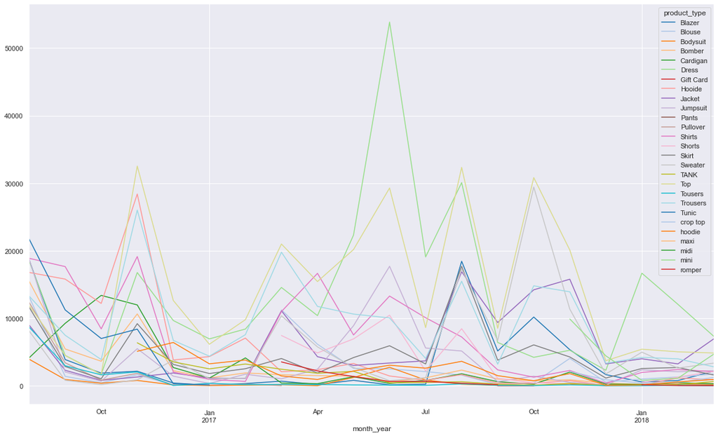

```python
camp = sns.color_palette('tab20')
df2_6.plot(figsize=(20,12), color=camp)
```

Some products show the seasonal feature. We can sale them together

## 2) Total order and total cost for each customer

```python
# Total number of order for each customer
df2_7 = orders[['customer_id','order_id']].groupby('customer_id').agg('count').sort_values(by=['order_id'],ascending=False)
df2_7.head()
```

| customer_id | order_id |
| --- | --- |
| 280479208957 | 355 |
| 413798176253 | 27 |
| 8689371999 | 25 |
| 8688688863 | 24 |
| 8689196063 | 20 |

```python
# Total cost for each customer
df2_8 = df2_4[['customer_id','order_item_sale']].groupby(['customer_id']).agg('sum')
df2_8.head()
```

| customer_id | order_item_sale |
| --- | --- |
| 8683754719 | 933.0 |
| 8686224991 | 87.0 |
| 8686913503 | 115.0 |
| 8686915935 | 240.0 |
| 8686924319 | 154.0 |

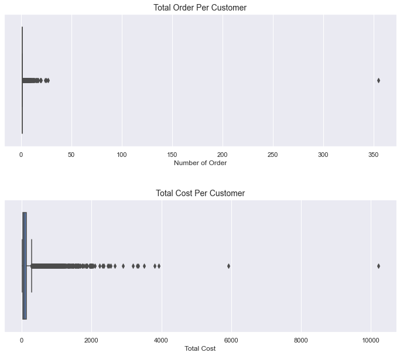

```python
f, ax = plt.subplots(figsize=(12, 10))
ax1 = plt.subplot(211)
sns.boxplot(df2_7['order_id'])
ax1.set_title('Total Order Per Customer',fontsize=14)
ax1.set_xlabel('Number of Order',fontsize=12)

ax2 = plt.subplot(212)
sns.boxplot(df2_8['order_item_sale'])
ax2.set_title('Total Cost Per Customer', fontsize=14)
ax2.set_xlabel('Total Cost', fontsize=12)

plt.subplots_adjust(hspace=0.4)

plt.show()
```

There is one customer has more than 350 orders when the common number is less than 50. The common number for total cost per customer is less than 2000, and the outlier is 10000+

# Part 3: Data Cleaning

## 1) Check outlier

```python
# Outlier of customer order
orders[['customer_id','order_id']].groupby('customer_id').agg('count').sort_values(by=['order_id'],ascending=False).head(1)
```

| customer_id | order_id |
| --- | --- |
| 280479208957 | 355 |

```python
# Check custoemr_id 280479208957 cost in each order
orders[orders['customer_id']==280479208957].groupby('total_price').agg('count')
# Customer_id 280479208957 has 343 orders with no cost, so this customer_is should be defined as a fake account
```

| total_price | order_id | order_created_at | order_closed_at | cancelled_at | customer_id | financial_status | fulfillment_status | processed_at | shipping_rate | subtotal_price | total_discounts | total_line_items_price |
| --- | --- | --- | --- | --- | --- | --- | --- | --- | --- | --- | --- | --- |
| 0.00 | 343 | 343 | 324 | 1 | 343 | 343 | 326 | 343 | 343 | 343 | 343 | 343 |
| 18.62 | 2 | 2 | 0 | 0 | 2 | 2 | 0 | 2 | 2 | 2 | 2 | 2 |
| 28.00 | 1 | 1 | 0 | 0 | 1 | 1 | 0 | 1 | 1 | 1 | 1 | 1 |
| 28.47 | 1 | 1 | 1 | 0 | 1 | 1 | 1 | 1 | 1 | 1 | 1 | 1 |
| 43.25 | 1 | 1 | 0 | 0 | 1 | 1 | 0 | 1 | 1 | 1 | 1 | 1 |
| 122.64 | 1 | 1 | 1 | 0 | 1 | 1 | 1 | 1 | 1 | 1 | 1 | 1 |
| 127.15 | 1 | 1 | 0 | 0 | 1 | 1 | 1 | 1 | 1 | 1 | 1 | 1 |
| 209.00 | 1 | 1 | 0 | 0 | 1 | 1 | 1 | 1 | 1 | 1 | 1 | 1 |
| 235.97 | 1 | 1 | 0 | 0 | 1 | 1 | 1 | 1 | 1 | 1 | 1 | 1 |
| 241.00 | 1 | 1 | 0 | 0 | 1 | 1 | 1 | 1 | 1 | 1 | 1 | 1 |
| 296.00 | 1 | 1 | 0 | 0 | 1 | 1 | 1 | 1 | 1 | 1 | 1 | 1 |
| 308.17 | 1 | 1 | 0 | 0 | 1 | 1 | 1 | 1 | 1 | 1 | 1 | 1 |

```python
# Delete custoemr_id 280479208957
fake_orders = orders[orders['customer_id']==280479208957]['order_id'].tolist()
customers.drop(customers.loc[customers['id']==280479208957].index, inplace=True)
orders.drop(orders.loc[orders['customer_id']==280479208957].index, inplace=True)
orders_items.drop(orders_items.loc[orders_items['order_id'].isin(fake_orders)].index, inplace=True)
```

```python
# Double check customer_id 280479208957
orders[orders['customer_id']==280479208957][['order_created_at','total_price']]
```

|  | order_created_at | total_price |
| --- | --- | --- |

```python
# Outlier of customer order
df2_8[['order_item_sale']].groupby('customer_id').agg('sum').sort_values(by=['order_item_sale'],ascending=False).head(1)
# Customer_id 8689196063 has the most total cost
```

| customer_id | order_item_sale |
| --- | --- |
| 8689196063 | 10218.0 |

```python
# Check cost of each order of customer_id 8689196063
orders[orders['customer_id']==8689196063].groupby('total_price').agg('count')
# This cusomer_id looks not a fake account
```

| total_price | order_id | order_created_at | order_closed_at | cancelled_at | customer_id | financial_status | fulfillment_status | processed_at | shipping_rate | subtotal_price | total_discounts | total_line_items_price |
| --- | --- | --- | --- | --- | --- | --- | --- | --- | --- | --- | --- | --- |
| 15.76 | 1 | 1 | 1 | 0 | 1 | 1 | 1 | 1 | 1 | 1 | 1 | 1 |
| 101.17 | 2 | 2 | 2 | 0 | 2 | 2 | 2 | 2 | 2 | 2 | 2 | 2 |
| 110.98 | 1 | 1 | 1 | 0 | 1 | 1 | 1 | 1 | 1 | 1 | 1 | 1 |
| 113.88 | 1 | 1 | 1 | 0 | 1 | 1 | 1 | 1 | 1 | 1 | 1 | 1 |
| 127.02 | 1 | 1 | 1 | 0 | 1 | 1 | 1 | 1 | 1 | 1 | 1 | 1 |
| 134.69 | 1 | 1 | 1 | 0 | 1 | 1 | 1 | 1 | 1 | 1 | 1 | 1 |
| 147.83 | 1 | 1 | 1 | 0 | 1 | 1 | 1 | 1 | 1 | 1 | 1 | 1 |
| 187.91 | 1 | 1 | 1 | 0 | 1 | 1 | 1 | 1 | 1 | 1 | 1 | 1 |
| 226.67 | 1 | 1 | 1 | 0 | 1 | 1 | 1 | 1 | 1 | 1 | 1 | 1 |
| 231.05 | 1 | 1 | 1 | 0 | 1 | 1 | 1 | 1 | 1 | 1 | 1 | 1 |
| 259.68 | 1 | 1 | 0 | 0 | 1 | 1 | 1 | 1 | 1 | 1 | 1 | 1 |
| 315.71 | 1 | 1 | 1 | 0 | 1 | 1 | 1 | 1 | 1 | 1 | 1 | 1 |
| 358.07 | 1 | 1 | 1 | 0 | 1 | 1 | 1 | 1 | 1 | 1 | 1 | 1 |
| 362.71 | 1 | 1 | 1 | 0 | 1 | 1 | 1 | 1 | 1 | 1 | 1 | 1 |
| 376.05 | 1 | 1 | 1 | 0 | 1 | 1 | 1 | 1 | 1 | 1 | 1 | 1 |
| 440.72 | 1 | 1 | 1 | 0 | 1 | 1 | 1 | 1 | 1 | 1 | 1 | 1 |
| 459.94 | 1 | 1 | 1 | 0 | 1 | 1 | 1 | 1 | 1 | 1 | 1 | 1 |
| 464.28 | 1 | 1 | 0 | 0 | 1 | 1 | 1 | 1 | 1 | 1 | 1 | 1 |
| 660.29 | 1 | 1 | 1 | 0 | 1 | 1 | 1 | 1 | 1 | 1 | 1 | 1 |

## 2) Check duplicate rows

```python
# Customers Dataset
row_count = customers['id'].count()
unique_row_count = customers['id'].nunique()
print(row_count)
print(unique_row_count)
```

```
44660
44660
```

```python
# Orders_items Dataset
row_count = orders_items['orders_items_id'].count()
unique_row_count = orders_items['orders_items_id'].nunique()
print(row_count)
print(unique_row_count)
```

```
35495
35495
```

```python
# Orders Dataset
row_count = orders['order_id'].count()
unique_row_count = orders['order_id'].nunique()
print(row_count)
print(unique_row_count)
```

```
21003
21003
```

```python
# Products_skus Dataset
row_count = products_skus['id'].count()
unique_row_count = products_skus['id'].nunique()
print(row_count)
print(unique_row_count)
```

```
1356
1356
```

```python
# Products Dataset
row_count = products['product_id'].count()
unique_row_count = products['product_id'].nunique()
print(row_count)
print(unique_row_count)
```

```
247
247
```

```python
# Traffic Dataset
row_count = traffic['index'].count()
unique_row_count = traffic['index'].nunique()
print(row_count)
print(unique_row_count)
```

```
579
579
```

```python
# Transactions Dataset
row_count = transactions['id'].count()
unique_row_count = transactions['id'].nunique()
print(row_count)
print(unique_row_count)
```

```
27563
27563
```

No Duplicate in Dataset

## 3) Check Missing Values

```python
# Customers Dataset
print('total rows: ({} rows)'.format(customers.shape[0]))
print(customers.isnull().sum())
```

```
total rows: (44660 rows)
id                0
full_name     10962
created_at        0
dtype: int64
```

```python
# Orders_items Dataset
print('total rows: ({} rows)'.format(orders_items.shape[0]))
print(orders_items.isnull().sum())
```

```
total rows: (35495 rows)
orders_items_id          0
order_id                 0
product_id              24
product_style            0
variant_id               0
sku                      0
product_title            0
fulfillment_status    1387
price                    0
quantity                 0
dtype: int64
```

```python
# Orders Dataset
print('total rows: ({} rows)'.format(orders.shape[0]))
print(orders.isnull().sum())
```

```
total rows: (21003 rows)
order_id                      0
order_created_at              0
order_closed_at            1134
cancelled_at              20594
customer_id                   0
financial_status              0
fulfillment_status          657
processed_at                  0
total_price                   0
shipping_rate                 0
subtotal_price                0
total_discounts               0
total_line_items_price        0
dtype: int64
```

```python
# Products_skus Dataset
print('total rows: ({} rows)'.format(products_skus.shape[0]))
print(products_skus.isnull().sum())
```

```
total rows: (1356 rows)
id               0
product_id       0
product_style    0
sku              0
created_at       0
price            0
dtype: int64
```

```python
# Products Dataset
print('total rows: ({} rows)'.format(products.shape[0]))
print(products.isnull().sum())
```

```
total rows: (247 rows)
product_id               0
title                    0
product_type             5
product_create_at        0
product_published_at    24
dtype: int64
```

```python
# Traffic Dataset
print('total rows: ({} rows)'.format(traffic.shape[0]))
print(traffic.isnull().sum())
```

```
total rows: (579 rows)
index                    0
date_day                 0
page_views               0
sessions                 0
product_detail_views     0
product_checkouts        0
product_adds_to_carts    0
avg_session_in_s         0
dtype: int64
```

```python
# Transactions Dataset
print('total rows: ({} rows)'.format(transactions.shape[0]))
print(transactions.isnull().sum())
```

```
total rows: (27563 rows)
order_id          0
id                0
parent_id     22686
amount            0
error_code    25920
kind              0
status            0
created_at        0
dtype: int64
```

## 4) Check Tepo

```python
products['product_type'].unique()
```

```
array(['Dress', 'Bomber', 'Shirts', 'Blazer', 'Hooide', 'Tunic', 'Blouse',
       'Skirt', 'Top', 'TANK', 'Tousers', 'Sweater', 'Cardigan',
       'Trousers', 'Jumpsuit', 'Gift Card', 'hoodie', 'Jacket', 'romper',
       'Shorts', 'mini', 'Bodysuit', nan, 'crop top', 'Pullover', 'Pants',
       'maxi', 'midi', 'Accessory'], dtype=object)
```

```python
spelling = {'Hooide': 'Hoodie', 'TANK': 'Tank', 'Tousers': 'Trousers',
            'hoodie': 'Hoodie', 'romper': 'Romper', 'mini': 'Mini',
            'crop top': 'Crop Top', 'maxi': 'Maxi', 'midi': 'Midi'}
products['product_type'].replace(spelling, inplace=True)
products['product_type'].unique()
```

```
array(['Dress', 'Bomber', 'Shirts', 'Blazer', 'Hoodie', 'Tunic', 'Blouse',
       'Skirt', 'Top', 'Tank', 'Trousers', 'Sweater', 'Cardigan',
       'Jumpsuit', 'Gift Card', 'Jacket', 'Romper', 'Shorts', 'Mini',
       'Bodysuit', nan, 'Crop Top', 'Pullover', 'Pants', 'Maxi', 'Midi',
       'Accessory'], dtype=object)
```

# Part4: Website traffic and correlation

## 1) How’s the trend of website traffic and the number of orders over time?

```python
orders['order_created_at'] = pd.to_datetime(orders['order_created_at'])
num_of_orders = orders.groupby('order_created_at').count()
num_of_orders.head()
```

| order_created_at | order_id | order_closed_at | cancelled_at | customer_id | financial_status | fulfillment_status | processed_at | total_price | shipping_rate | subtotal_price | total_discounts | total_line_items_price |
| --- | --- | --- | --- | --- | --- | --- | --- | --- | --- | --- | --- | --- |
| 2016-08-21 | 1 | 1 | 1 | 1 | 1 | 0 | 1 | 1 | 1 | 1 | 1 | 1 |
| 2016-08-22 | 794 | 780 | 16 | 794 | 794 | 775 | 794 | 794 | 794 | 794 | 794 | 794 |
| 2016-08-23 | 183 | 179 | 4 | 183 | 183 | 180 | 183 | 183 | 183 | 183 | 183 | 183 |
| 2016-08-24 | 44 | 43 | 0 | 44 | 44 | 44 | 44 | 44 | 44 | 44 | 44 | 44 |
| 2016-08-25 | 62 | 61 | 3 | 62 | 62 | 54 | 62 | 62 | 62 | 62 | 62 | 62 |

```python
traffic['date_day'] = pd.to_datetime(traffic['date_day'])
```

```python
# Merge traffic and num_of_orders table
df_q1 = pd.merge(traffic, num_of_orders, how='inner', left_on = 'date_day', right_on='order_created_at')
df_q1 = df_q1.rename(columns = {'order_id': 'order_num'})
df_q1.head()
```

|  | index | date_day | page_views | sessions | product_detail_views | product_checkouts | product_adds_to_carts | avg_session_in_s | order_num | order_closed_at | cancelled_at | customer_id | financial_status | fulfillment_status | processed_at | total_price | shipping_rate | subtotal_price | total_discounts | total_line_items_price |
| --- | --- | --- | --- | --- | --- | --- | --- | --- | --- | --- | --- | --- | --- | --- | --- | --- | --- | --- | --- | --- |
| 0 | 4 | 2016-08-21 | 10276 | 4946 | 0 | 0 | 0 | 73.470481 | 1 | 1 | 1 | 1 | 1 | 0 | 1 | 1 | 1 | 1 | 1 | 1 |
| 1 | 5 | 2016-08-22 | 625003 | 146860 | 175257 | 5639 | 10851 | 142.407837 | 794 | 780 | 16 | 794 | 794 | 775 | 794 | 794 | 794 | 794 | 794 | 794 |
| 2 | 6 | 2016-08-23 | 220707 | 61654 | 58940 | 761 | 1817 | 106.161449 | 183 | 179 | 4 | 183 | 183 | 180 | 183 | 183 | 183 | 183 | 183 | 183 |
| 3 | 7 | 2016-08-24 | 93694 | 27182 | 24935 | 256 | 638 | 98.999669 | 44 | 43 | 0 | 44 | 44 | 44 | 44 | 44 | 44 | 44 | 44 | 44 |
| 4 | 8 | 2016-08-25 | 63927 | 15239 | 19167 | 901 | 1826 | 130.410854 | 62 | 61 | 3 | 62 | 62 | 54 | 62 | 62 | 62 | 62 | 62 | 62 |

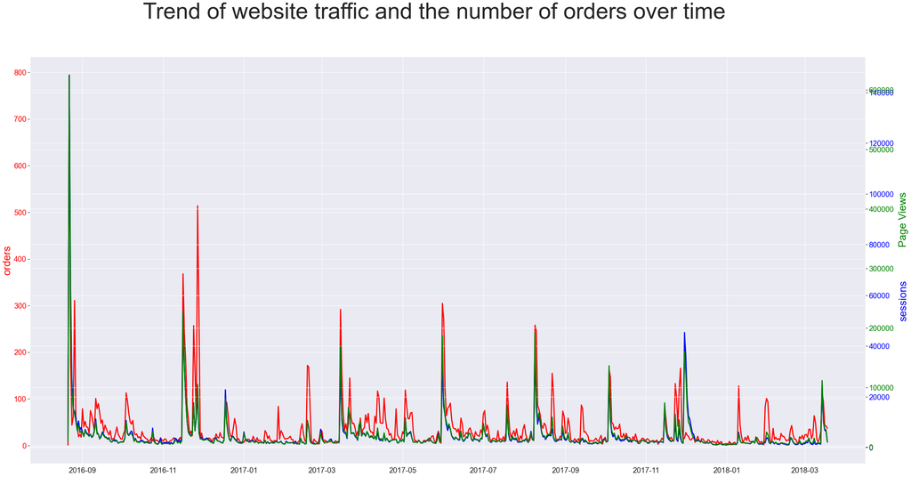

```python
fig, ax1 = plt.subplots(figsize=(40,20))
fig.suptitle('Trend of website traffic and the number of orders over time', fontsize=60)
color = 'tab:cyan'
color = 'red'
ax1.set_ylabel('orders', color=color, fontsize=28)
ax1.plot(df_q1['date_day'], df_q1['order_num'], color=color, linewidth=3)
ax1.tick_params(axis='y', labelcolor=color)
plt.xticks(size=20)
plt.yticks(size=20)


ax2 = ax1.twinx()
color = 'blue'
ax2.set_xlabel('Time Period', fontsize=28)
ax2.set_ylabel('sessions', color = color, fontsize=28)
ax2.plot(df_q1['date_day'], df_q1['sessions'], color = color, linewidth=3)
ax2.tick_params(axis='y', labelcolor=color)
plt.xticks(size=20)
plt.yticks(size=20)
ax2.yaxis.set_label_coords(1.04,.4)

ax3 = ax1.twinx()
color = 'green'
ax3.set_xlabel('Time Period', fontsize=28)
ax3.set_ylabel('Page Views', color=color, fontsize=28)
ax3.plot(df_q1['date_day'], df_q1['page_views'], color=color, linewidth=3)
ax3.tick_params(axis='y', labelcolor=color)
plt.xticks(size=20)
plt.yticks(size=20)
ax3.yaxis.set_label_coords(1.04,.6)


plt.show()
```

Basically, the trend of the number of orders has a strong relationship with the number of page views and sessions. Overall, there is a decreasing trend year by year.

## 2) Is there any correlation between the orders and the website traffic?

```python
df_q1.head()
```

|  | index | date_day | page_views | sessions | product_detail_views | product_checkouts | product_adds_to_carts | avg_session_in_s | order_num | order_closed_at | cancelled_at | customer_id | financial_status | fulfillment_status | processed_at | total_price | shipping_rate | subtotal_price | total_discounts | total_line_items_price |
| --- | --- | --- | --- | --- | --- | --- | --- | --- | --- | --- | --- | --- | --- | --- | --- | --- | --- | --- | --- | --- |
| 0 | 4 | 2016-08-21 | 10276 | 4946 | 0 | 0 | 0 | 73.470481 | 1 | 1 | 1 | 1 | 1 | 0 | 1 | 1 | 1 | 1 | 1 | 1 |
| 1 | 5 | 2016-08-22 | 625003 | 146860 | 175257 | 5639 | 10851 | 142.407837 | 794 | 780 | 16 | 794 | 794 | 775 | 794 | 794 | 794 | 794 | 794 | 794 |
| 2 | 6 | 2016-08-23 | 220707 | 61654 | 58940 | 761 | 1817 | 106.161449 | 183 | 179 | 4 | 183 | 183 | 180 | 183 | 183 | 183 | 183 | 183 | 183 |
| 3 | 7 | 2016-08-24 | 93694 | 27182 | 24935 | 256 | 638 | 98.999669 | 44 | 43 | 0 | 44 | 44 | 44 | 44 | 44 | 44 | 44 | 44 | 44 |
| 4 | 8 | 2016-08-25 | 63927 | 15239 | 19167 | 901 | 1826 | 130.410854 | 62 | 61 | 3 | 62 | 62 | 54 | 62 | 62 | 62 | 62 | 62 | 62 |

```python
df_corr = df_q1[['order_num', 'page_views', 'sessions', 'avg_session_in_s', 'product_detail_views', 'product_adds_to_carts', 'product_checkouts', 'total_discounts']].corr()
df_corr
```

|  | order_num | page_views | sessions | avg_session_in_s | product_detail_views | product_adds_to_carts | product_checkouts | total_discounts |
| --- | --- | --- | --- | --- | --- | --- | --- | --- |
| order_num | 1.000000 | 0.815809 | 0.770344 | 0.261292 | 0.828847 | 0.841659 | 0.897855 | 1.000000 |
| page_views | 0.815809 | 1.000000 | 0.989081 | 0.150182 | 0.984876 | 0.863625 | 0.910663 | 0.815809 |
| sessions | 0.770344 | 0.989081 | 1.000000 | 0.070872 | 0.959438 | 0.793949 | 0.867374 | 0.770344 |
| avg_session_in_s | 0.261292 | 0.150182 | 0.070872 | 1.000000 | 0.173966 | 0.327379 | 0.235011 | 0.261292 |
| product_detail_views | 0.828847 | 0.984876 | 0.959438 | 0.173966 | 1.000000 | 0.898455 | 0.921408 | 0.828847 |
| product_adds_to_carts | 0.841659 | 0.863625 | 0.793949 | 0.327379 | 0.898455 | 1.000000 | 0.903816 | 0.841659 |
| product_checkouts | 0.897855 | 0.910663 | 0.867374 | 0.235011 | 0.921408 | 0.903816 | 1.000000 | 0.897855 |
| total_discounts | 1.000000 | 0.815809 | 0.770344 | 0.261292 | 0.828847 | 0.841659 | 0.897855 | 1.000000 |

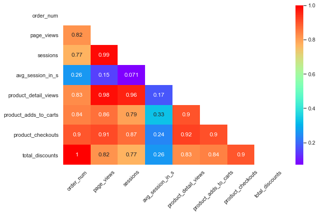

```python
# Correlation visualization
plt.figure(figsize=(10,6))
mask = np.zeros_like(df_corr)
mask[np.triu_indices_from(mask)] = True
with sns.axes_style('white'):
    sns.heatmap(df_corr, annot=True, cmap='rainbow', mask=mask)
plt.xticks(rotation=45)
plt.show()
```

Based on the heatmap, the result shows a positive correlation between page views, sessions, and the number of orders. The coefficients are 0.82 and 0.77. Although both coefficients are positive, they are not the features that have the most effect on the total order number

# Part5: Sales and Products

## 1) How’s the sales from the different products over the seasons or months?

```python
# Merge orders_item and products table
df1_q2 = pd.merge(left=orders_items, right=products, how='left', on='product_id')
df1_q2.head()
```

|  | orders_items_id | order_id | product_id | product_style | variant_id | sku | product_title | fulfillment_status | price | quantity | title | product_type | product_create_at | product_published_at |
| --- | --- | --- | --- | --- | --- | --- | --- | --- | --- | --- | --- | --- | --- | --- |
| 0 | 13325125855 | 7675398239 | 12927629215.0 | 2c259a42d38f5f097274beff811168e2 | 50547057311 | 000d96b3b77b33af530eec77689bd210 | 5cfd6c4e00b25e6dec5538928206b7b8 | NaN | 35.0 | 1 | 5cfd6c4e00b25e6dec5538928206b7b8 | Tunic | 2016-08-18 | NaN |
| 1 | 13327045983 | 7676331935 | 12927632095.0 | dd804c4025d230467823200aa82e9219 | 50547118303 | e26c77e84b91c9939c23c3e3ef66475a | 0e6e45ad42707e9732119f4b98aec7ce | NaN | 79.0 | 1 | 0e6e45ad42707e9732119f4b98aec7ce | Bomber | 2016-08-18 | 2016-08-18 |
| 2 | 13327109727 | 7676363167 | 12928055775.0 | f4e2e3c5433e4120889e2a7e0e0180a8 | 50553858975 | 0be0c8bf78ecf36416a40c9012acd19e | bede8c8f4e3c9c9d9a061d9a8d086cdc | NaN | 58.0 | 1 | bede8c8f4e3c9c9d9a061d9a8d086cdc | Trousers | 2016-08-18 | 2016-08-18 |
| 3 | 13327495903 | 7676539359 | 12927625695.0 | 08ba660ec5643520a73108bef6f3ddd6 | 50547001887 | 0503dec809a8a2600d9acc5249900ecb | 27d598cb953eff3667f7d051fe795284 | fulfilled | 25.0 | 1 | 27d598cb953eff3667f7d051fe795284 | Shirts | 2016-08-18 | 2018-02-05 |
| 4 | 13327518751 | 7676549855 | 12927690655.0 | 68ac90e5df73ae9b662174b21dc1586f | 50548035807 | 38de0d087208588510907b5c2d149e4b | 07dd8ba2ccadf3f3766750f10f6d05b5 | fulfilled | 25.0 | 1 | 07dd8ba2ccadf3f3766750f10f6d05b5 | Shirts | 2016-08-18 | NaN |

```python
# Merge df_q2 and orders table
df2_q2 = pd.merge(left=df1_q2, right=orders, how='left', on='order_id')

# Calculate order_item_sale
df2_q2['order_item_sale'] = df2_q2['price']*df2_q2['quantity']
df2_q2.head()
```

|  | orders_items_id | order_id | product_id | product_style | variant_id | sku | product_title | fulfillment_status_x | price | quantity | title | product_type | product_create_at | product_published_at | order_created_at | order_closed_at | cancelled_at | customer_id | financial_status | fulfillment_status_y | processed_at | total_price | shipping_rate | subtotal_price | total_discounts | total_line_items_price | order_item_sale |
| --- | --- | --- | --- | --- | --- | --- | --- | --- | --- | --- | --- | --- | --- | --- | --- | --- | --- | --- | --- | --- | --- | --- | --- | --- | --- | --- | --- |
| 0 | 13325125855 | 7675398239 | 12927629215.0 | 2c259a42d38f5f097274beff811168e2 | 50547057311 | 000d96b3b77b33af530eec77689bd210 | 5cfd6c4e00b25e6dec5538928206b7b8 | NaN | 35.0 | 1 | 5cfd6c4e00b25e6dec5538928206b7b8 | Tunic | 2016-08-18 | NaN | 2016-08-21 | 2016-08-25 | 2016-08-22 | 8683754719 | voided | NaN | 2016-08-21 | 44.57 | 6.33 | 35.0 | 0.0 | 35.0 | 35.0 |
| 1 | 13327045983 | 7676331935 | 12927632095.0 | dd804c4025d230467823200aa82e9219 | 50547118303 | e26c77e84b91c9939c23c3e3ef66475a | 0e6e45ad42707e9732119f4b98aec7ce | NaN | 79.0 | 1 | 0e6e45ad42707e9732119f4b98aec7ce | Bomber | 2016-08-18 | 2016-08-18 | 2016-08-22 | 2016-08-22 | NaN | 8686224991 | refunded | NaN | 2016-08-22 | 124.55 | 0.00 | 114.0 | 0.0 | 114.0 | 79.0 |
| 2 | 13327109727 | 7676363167 | 12928055775.0 | f4e2e3c5433e4120889e2a7e0e0180a8 | 50553858975 | 0be0c8bf78ecf36416a40c9012acd19e | bede8c8f4e3c9c9d9a061d9a8d086cdc | NaN | 58.0 | 1 | bede8c8f4e3c9c9d9a061d9a8d086cdc | Trousers | 2016-08-18 | 2016-08-18 | 2016-08-22 | NaN | 2016-08-22 | 8686224991 | voided | NaN | 2016-08-22 | 97.68 | 7.00 | 83.0 | 0.0 | 83.0 | 58.0 |
| 3 | 13327495903 | 7676539359 | 12927625695.0 | 08ba660ec5643520a73108bef6f3ddd6 | 50547001887 | 0503dec809a8a2600d9acc5249900ecb | 27d598cb953eff3667f7d051fe795284 | fulfilled | 25.0 | 1 | 27d598cb953eff3667f7d051fe795284 | Shirts | 2016-08-18 | 2018-02-05 | 2016-08-22 | 2016-08-22 | NaN | 8686915935 | paid | fulfilled | 2016-08-22 | 131.10 | 0.00 | 120.0 | 0.0 | 120.0 | 25.0 |
| 4 | 13327518751 | 7676549855 | 12927690655.0 | 68ac90e5df73ae9b662174b21dc1586f | 50548035807 | 38de0d087208588510907b5c2d149e4b | 07dd8ba2ccadf3f3766750f10f6d05b5 | fulfilled | 25.0 | 1 | 07dd8ba2ccadf3f3766750f10f6d05b5 | Shirts | 2016-08-18 | NaN | 2016-08-22 | 2016-08-22 | NaN | 8686924319 | paid | fulfilled | 2016-08-22 | 91.12 | 7.00 | 77.0 | 0.0 | 77.0 | 25.0 |

```python
# Merge df2_q2 and transactions table
df3_q2 = pd.merge(left=df2_q2, right=transactions, how='left', on='order_id')
df3_q2.head()
```

|  | orders_items_id | order_id | product_id | product_style | variant_id | sku | product_title | fulfillment_status_x | price | quantity | title | product_type | product_create_at | product_published_at | order_created_at | order_closed_at | cancelled_at | customer_id | financial_status | fulfillment_status_y | processed_at | total_price | shipping_rate | subtotal_price | total_discounts | total_line_items_price | order_item_sale | id | parent_id | … |
| --- | --- | --- | --- | --- | --- | --- | --- | --- | --- | --- | --- | --- | --- | --- | --- | --- | --- | --- | --- | --- | --- | --- | --- | --- | --- | --- | --- | --- | --- | --- |
| 0 | 13325125855 | 7675398239 | 12927629215.0 | 2c259a42d38f5f097274beff811168e2 | 50547057311 | 000d96b3b77b33af530eec77689bd210 | 5cfd6c4e00b25e6dec5538928206b7b8 | NaN | 35.0 | 1 | 5cfd6c4e00b25e6dec5538928206b7b8 | Tunic | 2016-08-18 | NaN | 2016-08-21 | 2016-08-25 | 2016-08-22 | 8683754719 | voided | NaN | 2016-08-21 | 44.57 | 6.33 | 35.0 | 0.0 | 35.0 | 35.0 | 8330669343 | NaN | … |
| 1 | 13325125855 | 7675398239 | 12927629215.0 | 2c259a42d38f5f097274beff811168e2 | 50547057311 | 000d96b3b77b33af530eec77689bd210 | 5cfd6c4e00b25e6dec5538928206b7b8 | NaN | 35.0 | 1 | 5cfd6c4e00b25e6dec5538928206b7b8 | Tunic | 2016-08-18 | NaN | 2016-08-21 | 2016-08-25 | 2016-08-22 | 8683754719 | voided | NaN | 2016-08-21 | 44.57 | 6.33 | 35.0 | 0.0 | 35.0 | 35.0 | 8331258783 | 8330669343.0 | … |
| 2 | 13327045983 | 7676331935 | 12927632095.0 | dd804c4025d230467823200aa82e9219 | 50547118303 | e26c77e84b91c9939c23c3e3ef66475a | 0e6e45ad42707e9732119f4b98aec7ce | NaN | 79.0 | 1 | 0e6e45ad42707e9732119f4b98aec7ce | Bomber | 2016-08-18 | 2016-08-18 | 2016-08-22 | 2016-08-22 | NaN | 8686224991 | refunded | NaN | 2016-08-22 | 124.55 | 0.00 | 114.0 | 0.0 | 114.0 | 79.0 | 8331688479 | NaN | … |
| 3 | 13327045983 | 7676331935 | 12927632095.0 | dd804c4025d230467823200aa82e9219 | 50547118303 | e26c77e84b91c9939c23c3e3ef66475a | 0e6e45ad42707e9732119f4b98aec7ce | NaN | 79.0 | 1 | 0e6e45ad42707e9732119f4b98aec7ce | Bomber | 2016-08-18 | 2016-08-18 | 2016-08-22 | 2016-08-22 | NaN | 8686224991 | refunded | NaN | 2016-08-22 | 124.55 | 0.00 | 114.0 | 0.0 | 114.0 | 79.0 | 8333317599 | 8331688479.0 | … |
| 4 | 13327045983 | 7676331935 | 12927632095.0 | dd804c4025d230467823200aa82e9219 | 50547118303 | e26c77e84b91c9939c23c3e3ef66475a | 0e6e45ad42707e9732119f4b98aec7ce | NaN | 79.0 | 1 | 0e6e45ad42707e9732119f4b98aec7ce | Bomber | 2016-08-18 | 2016-08-18 | 2016-08-22 | 2016-08-22 | NaN | 8686224991 | refunded | NaN | 2016-08-22 | 124.55 | 0.00 | 114.0 | 0.0 | 114.0 | 79.0 | 8333318239 | 8333317599.0 | … |

```python
# Select order_item status is fulfilled & transaction status is success
df_q2 = df3_q2[(df3_q2['fulfillment_status_x'] == 'fulfilled') & (df3_q2['status'] == 'success')]
# Add computing column YYYY-MM
df_q2['month_year'] = df_q2['order_created_at'].dt.to_period('M')
df_q2.head()
# Drop duplicates order_items_id and reset index
df_q2.drop_duplicates('orders_items_id', inplace=True)
df_q2.reset_index(drop=True, inplace=True)
df_q2.head()
```

|  | orders_items_id | order_id | product_id | product_style | variant_id | sku | product_title | fulfillment_status_x | price | quantity | title | product_type | product_create_at | product_published_at | order_created_at | order_closed_at | cancelled_at | customer_id | financial_status | fulfillment_status_y | processed_at | total_price | shipping_rate | subtotal_price | total_discounts | total_line_items_price | order_item_sale | id | parent_id | … |
| --- | --- | --- | --- | --- | --- | --- | --- | --- | --- | --- | --- | --- | --- | --- | --- | --- | --- | --- | --- | --- | --- | --- | --- | --- | --- | --- | --- | --- | --- | --- |
| 0 | 13327495903 | 7676539359 | 12927625695.0 | 08ba660ec5643520a73108bef6f3ddd6 | 50547001887 | 0503dec809a8a2600d9acc5249900ecb | 27d598cb953eff3667f7d051fe795284 | fulfilled | 25.0 | 1 | 27d598cb953eff3667f7d051fe795284 | Shirts | 2016-08-18 | 2018-02-05 | 2016-08-22 | 2016-08-22 | NaN | 8686915935 | paid | fulfilled | 2016-08-22 | 131.10 | 0.0 | 120.0 | 0.0 | 120.0 | 25.0 | 8331919391 | NaN | … |
| 1 | 13327518751 | 7676549855 | 12927690655.0 | 68ac90e5df73ae9b662174b21dc1586f | 50548035807 | 38de0d087208588510907b5c2d149e4b | 07dd8ba2ccadf3f3766750f10f6d05b5 | fulfilled | 25.0 | 1 | 07dd8ba2ccadf3f3766750f10f6d05b5 | Shirts | 2016-08-18 | NaN | 2016-08-22 | 2016-08-22 | NaN | 8686924319 | paid | fulfilled | 2016-08-22 | 91.12 | 7.0 | 77.0 | 0.0 | 77.0 | 25.0 | 8331930399 | NaN | … |
| 2 | 13327526495 | 7676553055 | 12950530079.0 | 8945e6be376ffa754e06840e4865cc24 | 50766799839 | 2931fc65c83f771a597527925ff97131 | 08bbf9d4710e8bdbfd07c763ecb2f9e3 | fulfilled | 68.0 | 1 | 08bbf9d4710e8bdbfd07c763ecb2f9e3 | Jumpsuit | 2016-08-21 | NaN | 2016-08-22 | 2016-08-22 | NaN | 8687041311 | paid | fulfilled | 2016-08-22 | 75.00 | 7.0 | 68.0 | 0.0 | 68.0 | 68.0 | 8331934431 | NaN | … |
| 3 | 13327549343 | 7676564127 | 12927629215.0 | 2c259a42d38f5f097274beff811168e2 | 50547057823 | 549684602f6a1e779751c80445d819fc | 5cfd6c4e00b25e6dec5538928206b7b8 | fulfilled | 35.0 | 1 | 5cfd6c4e00b25e6dec5538928206b7b8 | Tunic | 2016-08-18 | NaN | 2016-08-22 | 2016-08-22 | NaN | 8687317279 | paid | fulfilled | 2016-08-22 | 94.40 | 7.0 | 80.0 | 0.0 | 80.0 | 35.0 | 8331948191 | NaN | … |
| 4 | 13327555615 | 7676566815 | 12927625695.0 | 08ba660ec5643520a73108bef6f3ddd6 | 50547000799 | 273bbc291163d41f2458c6694dd40fa1 | 27d598cb953eff3667f7d051fe795284 | fulfilled | 25.0 | 1 | 27d598cb953eff3667f7d051fe795284 | Shirts | 2016-08-18 | 2018-02-05 | 2016-08-22 | 2016-08-22 | NaN | 8687317407 | paid | fulfilled | 2016-08-22 | 34.31 | 7.0 | 25.0 | 0.0 | 25.0 | 25.0 | 8331950623 | NaN | … |

```python
# Group by YYYY-MM and calculate the sum of order_item_sale
df_q2_1= df_q2[['month_year','order_item_sale']].groupby('month_year').agg('sum')
df_q2_1.head()
```

| month_year | order_item_sale |
| --- | --- |
| 2016-08 | 114898.0 |
| 2016-09 | 83748.0 |
| 2016-10 | 54266.0 |
| 2016-11 | 154067.4 |
| 2016-12 | 51654.0 |

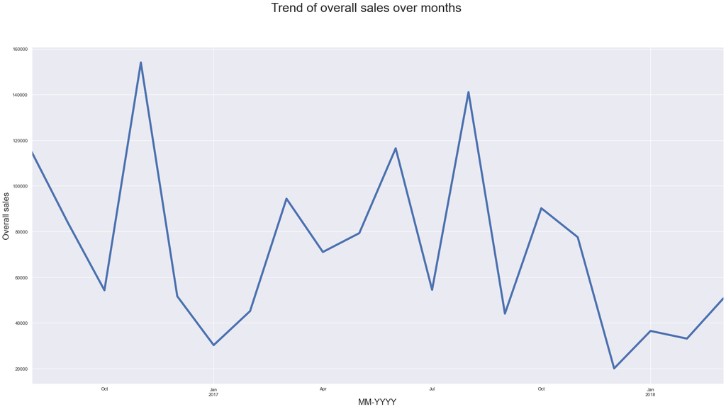

```python
# Create overall line chart
fig, ax = plt.subplots(figsize=(30,15))
df_q2_1['order_item_sale'].plot(linewidth=5)
fig.suptitle('Trend of overall sales over months', fontsize=30)
ax.set_xlabel('MM-YYYY', fontsize=20)
ax.set_ylabel('Overall sales',fontsize=20)

plt.show()
```

```python
# Trend of the sales from the different products over the months
```

```python
# Group by YYYY-MM and product type, calculate the sum of order_item_sale
df_q2_2=df_q2.groupby(['month_year', 'product_type']).agg('sum')['order_item_sale']
df_q2_3=df_q2_2.unstack('month_year').transpose()
df_q2_3.head()
```

| product_type month_year | Blazer | Blouse | Bodysuit | Bomber | Cardigan | Crop Top | Dress | Gift Card | Hoodie | Jacket | Jumpsuit | Maxi | Midi | Mini | Pants | Pullover | Romper | Shirts | Shorts | Skirt | Sweater | Tank | Top | Trousers | Tunic |
| --- | --- | --- | --- | --- | --- | --- | --- | --- | --- | --- | --- | --- | --- | --- | --- | --- | --- | --- | --- | --- | --- | --- | --- | --- | --- |
| 2016-08 | 9331.0 | 6230.0 | 1952.0 | 8058.0 | 1932.0 | NaN | 8716.0 | NaN | 9450.0 | 4340.0 | 7956.0 | NaN | NaN | NaN | NaN | 6594.0 | NaN | 11250.0 | NaN | 5628.0 | 4002.0 | NaN | 5910.0 | 11054.0 | 12495.0 |
| 2016-09 | 3216.0 | 1118.0 | 768.0 | 4582.0 | 7866.0 | NaN | 3670.0 | NaN | 14085.0 | 1798.0 | 1700.0 | NaN | NaN | NaN | NaN | 2940.0 | NaN | 16225.0 | NaN | 2223.0 | 696.0 | NaN | 3734.0 | 8977.0 | 10150.0 |
| 2016-10 | 1543.0 | 388.0 | 352.0 | 3081.0 | 12144.0 | NaN | 1692.0 | NaN | 11565.0 | 744.0 | 476.0 | NaN | NaN | NaN | NaN | 756.0 | NaN | 7800.0 | NaN | 851.0 | 174.0 | NaN | 1318.0 | 4907.0 | 6475.0 |
| 2016-11 | 1689.3 | 1216.6 | 614.4 | 8326.3 | 10536.3 | NaN | 13500.2 | NaN | 27141.5 | 1091.2 | 4120.8 | NaN | NaN | NaN | NaN | 1629.6 | NaN | 16582.5 | NaN | 6969.8 | 686.0 | 5377.0 | 25747.2 | 20979.2 | 6975.5 |
| 2016-12 | 340.0 | 104.0 | 96.0 | 2014.0 | 2418.0 | NaN | 7894.0 | NaN | 8392.0 | 1388.0 | 1020.0 | NaN | NaN | NaN | NaN | 126.0 | NaN | 1900.0 | NaN | 2713.0 | 3230.0 | 3109.0 | 11058.0 | 5537.0 | 315.0 |

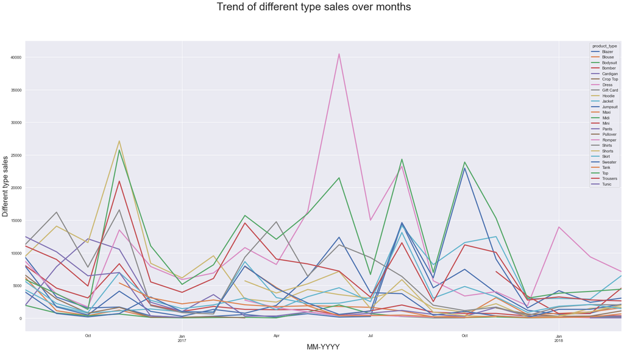

```python
# Create line chart for different product type
fig, ax = plt.subplots(figsize=(30,15))

df_q2_3.plot(ax=ax, linewidth=3)
fig.suptitle('Trend of different type sales over months', fontsize=30)
ax.set_xlabel('MM-YYYY', fontsize=20)
ax.set_ylabel('Different type sales',fontsize=20)

plt.show()
```

## 2)What are the popular products?

```python
# Group by product_type and calculate sum of order_item_sale, and sort
df_q2_4=df_q2[['product_type', 'order_item_sale']].groupby(['product_type']).agg('sum')
df_q2_4=df_q2_4.sort_values(by='order_item_sale', ascending=False)
df_q2_4.head()
```

| product_type | order_item_sale |
| --- | --- |
| Top | 218929.05 |
| Dress | 207772.86 |
| Trousers | 150484.70 |
| Shirts | 123520.20 |
| Hoodie | 115149.63 |

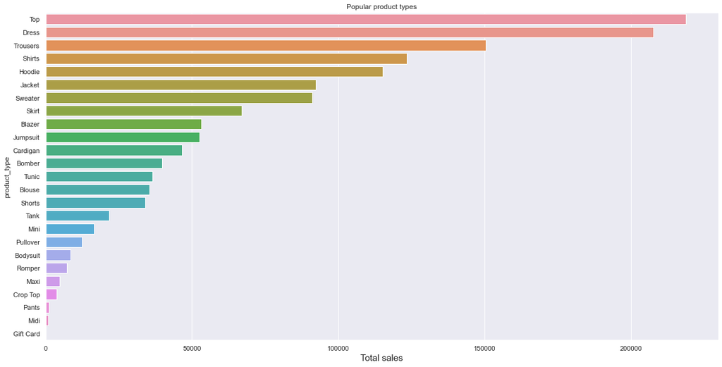

```python
# Create bar chart
fig, ax = plt.subplots(figsize=(20, 10))
ax = sns.barplot(x=df_q2_4['order_item_sale'],y=df_q2_4.index)
ax.set_xlabel('Total sales', fontsize=15)
ax.set_title('Popular product types')
plt.show()
```

## 3)Is there any correlation between different products?

```python
df_q2.head()
```

|  | orders_items_id | order_id | product_id | product_style | variant_id | sku | product_title | fulfillment_status_x | price | quantity | title | product_type | product_create_at | product_published_at | order_created_at | order_closed_at | cancelled_at | customer_id | financial_status | fulfillment_status_y | processed_at | total_price | shipping_rate | subtotal_price | total_discounts | total_line_items_price | order_item_sale | id | parent_id | … |
| --- | --- | --- | --- | --- | --- | --- | --- | --- | --- | --- | --- | --- | --- | --- | --- | --- | --- | --- | --- | --- | --- | --- | --- | --- | --- | --- | --- | --- | --- | --- |
| 0 | 13327495903 | 7676539359 | 12927625695.0 | 08ba660ec5643520a73108bef6f3ddd6 | 50547001887 | 0503dec809a8a2600d9acc5249900ecb | 27d598cb953eff3667f7d051fe795284 | fulfilled | 25.0 | 1 | 27d598cb953eff3667f7d051fe795284 | Shirts | 2016-08-18 | 2018-02-05 | 2016-08-22 | 2016-08-22 | NaN | 8686915935 | paid | fulfilled | 2016-08-22 | 131.10 | 0.0 | 120.0 | 0.0 | 120.0 | 25.0 | 8331919391 | NaN | … |
| 1 | 13327518751 | 7676549855 | 12927690655.0 | 68ac90e5df73ae9b662174b21dc1586f | 50548035807 | 38de0d087208588510907b5c2d149e4b | 07dd8ba2ccadf3f3766750f10f6d05b5 | fulfilled | 25.0 | 1 | 07dd8ba2ccadf3f3766750f10f6d05b5 | Shirts | 2016-08-18 | NaN | 2016-08-22 | 2016-08-22 | NaN | 8686924319 | paid | fulfilled | 2016-08-22 | 91.12 | 7.0 | 77.0 | 0.0 | 77.0 | 25.0 | 8331930399 | NaN | … |
| 2 | 13327526495 | 7676553055 | 12950530079.0 | 8945e6be376ffa754e06840e4865cc24 | 50766799839 | 2931fc65c83f771a597527925ff97131 | 08bbf9d4710e8bdbfd07c763ecb2f9e3 | fulfilled | 68.0 | 1 | 08bbf9d4710e8bdbfd07c763ecb2f9e3 | Jumpsuit | 2016-08-21 | NaN | 2016-08-22 | 2016-08-22 | NaN | 8687041311 | paid | fulfilled | 2016-08-22 | 75.00 | 7.0 | 68.0 | 0.0 | 68.0 | 68.0 | 8331934431 | NaN | … |
| 3 | 13327549343 | 7676564127 | 12927629215.0 | 2c259a42d38f5f097274beff811168e2 | 50547057823 | 549684602f6a1e779751c80445d819fc | 5cfd6c4e00b25e6dec5538928206b7b8 | fulfilled | 35.0 | 1 | 5cfd6c4e00b25e6dec5538928206b7b8 | Tunic | 2016-08-18 | NaN | 2016-08-22 | 2016-08-22 | NaN | 8687317279 | paid | fulfilled | 2016-08-22 | 94.40 | 7.0 | 80.0 | 0.0 | 80.0 | 35.0 | 8331948191 | NaN | … |
| 4 | 13327555615 | 7676566815 | 12927625695.0 | 08ba660ec5643520a73108bef6f3ddd6 | 50547000799 | 273bbc291163d41f2458c6694dd40fa1 | 27d598cb953eff3667f7d051fe795284 | fulfilled | 25.0 | 1 | 27d598cb953eff3667f7d051fe795284 | Shirts | 2016-08-18 | 2018-02-05 | 2016-08-22 | 2016-08-22 | NaN | 8687317407 | paid | fulfilled | 2016-08-22 | 34.31 | 7.0 | 25.0 | 0.0 | 25.0 | 25.0 | 8331950623 | NaN | … |

```python
order_item1 = df_q2[df_q2.fulfillment_status_y == 'fulfilled']
order_item2 = df_q2[df_q2.fulfillment_status_y == 'fulfilled']
```

```python
df_q2_5 = pd.merge(left=order_item1, right=order_item2, how='inner', on='order_id')
df_q2_6 = df_q2_5[df_q2_5.product_id_x != df_q2_5.product_id_y]
df_q2_6.head()
```

|  | orders_items_id_x | order_id | product_id_x | product_style_x | variant_id_x | sku_x | product_title_x | fulfillment_status_x_x | price_x | quantity_x | title_x | product_type_x | product_create_at_x | product_published_at_x | order_created_at_x | order_closed_at_x | cancelled_at_x | customer_id_x | financial_status_x | fulfillment_status_y_x | processed_at_x | total_price_x | shipping_rate_x | subtotal_price_x | total_discounts_x | total_line_items_price_x | order_item_sale_x | id_x | parent_id_x | … |
| --- | --- | --- | --- | --- | --- | --- | --- | --- | --- | --- | --- | --- | --- | --- | --- | --- | --- | --- | --- | --- | --- | --- | --- | --- | --- | --- | --- | --- | --- | --- |
| 1 | 13327495903 | 7676539359 | 12927625695.0 | 08ba660ec5643520a73108bef6f3ddd6 | 50547001887 | 0503dec809a8a2600d9acc5249900ecb | 27d598cb953eff3667f7d051fe795284 | fulfilled | 25.0 | 1 | 27d598cb953eff3667f7d051fe795284 | Shirts | 2016-08-18 | 2018-02-05 | 2016-08-22 | 2016-08-22 | NaN | 8686915935 | paid | fulfilled | 2016-08-22 | 131.1 | 0.0 | 120.0 | 0.0 | 120.0 | 25.0 | 8331919391 | NaN | … |
| 2 | 13327495903 | 7676539359 | 12927625695.0 | 08ba660ec5643520a73108bef6f3ddd6 | 50547001887 | 0503dec809a8a2600d9acc5249900ecb | 27d598cb953eff3667f7d051fe795284 | fulfilled | 25.0 | 1 | 27d598cb953eff3667f7d051fe795284 | Shirts | 2016-08-18 | 2018-02-05 | 2016-08-22 | 2016-08-22 | NaN | 8686915935 | paid | fulfilled | 2016-08-22 | 131.1 | 0.0 | 120.0 | 0.0 | 120.0 | 25.0 | 8331919391 | NaN | … |
| 4 | 13327495967 | 7676539359 | 12927690655.0 | 68ac90e5df73ae9b662174b21dc1586f | 50548035935 | 0871fce3fac653a5b430adf1eeb66242 | 07dd8ba2ccadf3f3766750f10f6d05b5 | fulfilled | 25.0 | 1 | 07dd8ba2ccadf3f3766750f10f6d05b5 | Shirts | 2016-08-18 | NaN | 2016-08-22 | 2016-08-22 | NaN | 8686915935 | paid | fulfilled | 2016-08-22 | 131.1 | 0.0 | 120.0 | 0.0 | 120.0 | 25.0 | 8331919391 | NaN | … |
| 6 | 13327495967 | 7676539359 | 12927690655.0 | 68ac90e5df73ae9b662174b21dc1586f | 50548035935 | 0871fce3fac653a5b430adf1eeb66242 | 07dd8ba2ccadf3f3766750f10f6d05b5 | fulfilled | 25.0 | 1 | 07dd8ba2ccadf3f3766750f10f6d05b5 | Shirts | 2016-08-18 | NaN | 2016-08-22 | 2016-08-22 | NaN | 8686915935 | paid | fulfilled | 2016-08-22 | 131.1 | 0.0 | 120.0 | 0.0 | 120.0 | 25.0 | 8331919391 | NaN | … |
| 7 | 13327495967 | 7676539359 | 12927690655.0 | 68ac90e5df73ae9b662174b21dc1586f | 50548035935 | 0871fce3fac653a5b430adf1eeb66242 | 07dd8ba2ccadf3f3766750f10f6d05b5 | fulfilled | 25.0 | 1 | 07dd8ba2ccadf3f3766750f10f6d05b5 | Shirts | 2016-08-18 | NaN | 2016-08-22 | 2016-08-22 | NaN | 8686915935 | paid | fulfilled | 2016-08-22 | 131.1 | 0.0 | 120.0 | 0.0 | 120.0 | 25.0 | 8331919391 | NaN | … |

```python
df_purchased_together = df_q2_6[['product_type_x', 'product_type_y', 'orders_items_id_x']].groupby(['product_type_x', 'product_type_y']).agg('count')
df_purchased_together = df_purchased_together.rename(columns={'orders_items_id_x':'purchased_counts'})
df_purchased_together.reset_index(level=['product_type_x','product_type_y'],inplace=True)
df_purchased_together = df_purchased_together.rename(columns={'product_type_x':'product_type', 'product_type_y':'product_type_purchased_together'})
df_purchased_together.head()
```

|  | product_type | product_type_purchased_together | purchased_counts |
| --- | --- | --- | --- |
| 0 | Blazer | Blazer | 70 |
| 1 | Blazer | Blouse | 17 |
| 2 | Blazer | Bodysuit | 17 |
| 3 | Blazer | Bomber | 14 |
| 4 | Blazer | Cardigan | 17 |

```python
df_orders = order_item1[['product_type', 'orders_items_id']].groupby(['product_type']).agg('count')
df_orders = df_orders.rename(columns={'orders_items_id':'num_orders'})
df_orders.reset_index(level='product_type',inplace=True)
df_orders.head()
```

|  | product_type | num_orders |
| --- | --- | --- |
| 0 | Blazer | 763 |
| 1 | Blouse | 814 |
| 2 | Bodysuit | 251 |
| 3 | Bomber | 618 |
| 4 | Cardigan | 794 |

```python
purchased = pd.merge(left=df_purchased_together, right=df_orders, how='left', on='product_type')
purchased.head()
```

|  | product_type | product_type_purchased_together | purchased_counts | num_orders |
| --- | --- | --- | --- | --- |
| 0 | Blazer | Blazer | 70 | 763 |
| 1 | Blazer | Blouse | 17 | 763 |
| 2 | Blazer | Bodysuit | 17 | 763 |
| 3 | Blazer | Bomber | 14 | 763 |
| 4 | Blazer | Cardigan | 17 | 763 |

```python
purchased['percentage_purchased_together'] = purchased.purchased_counts/purchased.num_orders
pd.set_option('display.precision',10)
purchased.sort_values(by='percentage_purchased_together', ascending=False).head()
```

|  | product_type | product_type_purchased_together | purchased_counts | num_orders | percentage_purchased_together |
| --- | --- | --- | --- | --- | --- |
| 121 | Crop Top | Trousers | 63 | 93 | 0.6774193548 |
| 333 | Shorts | Top | 536 | 827 | 0.6481257557 |
| 354 | Skirt | Top | 918 | 1504 | 0.6103723404 |
| 289 | Romper | Top | 107 | 183 | 0.5846994536 |
| 443 | Trousers | Top | 1345 | 2612 | 0.5149310873 |

```python
hm_df=purchased.pivot('product_type','product_type_purchased_together','percentage_purchased_together')
hm_df
```

| product_type_purchased_together product_type | Blazer | Blouse | Bodysuit | Bomber | Cardigan | Crop Top | Dress | Hoodie | Jacket | Jumpsuit | Maxi | Midi | Mini | Pants | Pullover | Romper | Shirts | Shorts | Skirt | Sweater | Tank | Top | Trousers | Tunic |
| --- | --- | --- | --- | --- | --- | --- | --- | --- | --- | --- | --- | --- | --- | --- | --- | --- | --- | --- | --- | --- | --- | --- | --- | --- |
| Blazer | 0.0917431193 | 0.0222804718 | 0.0222804718 | 0.0183486239 | 0.0222804718 | 0.0065530799 | 0.1205766710 | 0.0615989515 | 0.0969855832 | 0.0393184797 | 0.0013106160 | NaN | 0.0039318480 | 0.0052424640 | 0.0157273919 | NaN | 0.1022280472 | 0.0930537353 | 0.2070773263 | 0.1009174312 | 0.0039318480 | 0.2883355177 | 0.1834862385 | 0.0419397117 |
| Blouse | 0.0208845209 | 0.1154791155 | 0.0282555283 | 0.0245700246 | 0.0122850123 | 0.0098280098 | 0.2420147420 | 0.0614250614 | 0.0958230958 | 0.0356265356 | 0.0024570025 | 0.0012285012 | 0.0294840295 | NaN | 0.0135135135 | 0.0552825553 | 0.1302211302 | 0.1388206388 | 0.1203931204 | 0.0958230958 | 0.0282555283 | 0.4643734644 | 0.1879606880 | 0.0221130221 |
| Bodysuit | 0.0677290837 | 0.0916334661 | 0.0159362550 | 0.0199203187 | 0.0278884462 | NaN | 0.3466135458 | 0.0557768924 | 0.0557768924 | 0.1115537849 | NaN | NaN | 0.0039840637 | NaN | 0.0318725100 | 0.0039840637 | 0.2749003984 | 0.0996015936 | 0.0956175299 | 0.0398406375 | 0.0398406375 | 0.3824701195 | 0.1912350598 | 0.0597609562 |
| Bomber | 0.0226537217 | 0.0323624595 | 0.0080906149 | 0.0097087379 | 0.0631067961 | NaN | 0.0841423948 | 0.1488673139 | 0.0566343042 | 0.0194174757 | NaN | NaN | NaN | NaN | 0.0226537217 | 0.0016181230 | 0.1407766990 | 0.0226537217 | 0.0582524272 | 0.0404530744 | 0.0258899676 | 0.1585760518 | 0.0873786408 | 0.1197411003 |
| Cardigan | 0.0214105793 | 0.0125944584 | 0.0088161209 | 0.0491183879 | NaN | 0.0012594458 | 0.1234256927 | 0.1309823678 | 0.0264483627 | 0.0251889169 | NaN | NaN | 0.0012594458 | NaN | 0.0100755668 | 0.0012594458 | 0.1473551637 | 0.0050377834 | 0.0629722922 | 0.0403022670 | 0.0251889169 | 0.1549118388 | 0.0806045340 | 0.0629722922 |
| Crop Top | 0.0537634409 | 0.0860215054 | NaN | NaN | 0.0107526882 | 0.0430107527 | 0.1397849462 | 0.0215053763 | 0.1720430108 | 0.0322580645 | NaN | 0.0107526882 | 0.2150537634 | 0.0215053763 | NaN | NaN | 0.0215053763 | 0.0537634409 | 0.0645161290 | 0.0752688172 | 0.0215053763 | 0.2258064516 | 0.6774193548 | NaN |
| Dress | 0.0228685061 | 0.0489684315 | 0.0216256525 | 0.0129256774 | 0.0243599304 | 0.0032314193 | 0.2754163560 | 0.0748197862 | 0.0487198608 | 0.0579169774 | 0.0012428536 | NaN | 0.0069599801 | NaN | 0.0052199851 | 0.0089485459 | 0.0979368630 | 0.0715883669 | 0.0991797166 | 0.0469798658 | 0.0410141685 | 0.3552075565 | 0.0986825752 | 0.0121799652 |
| Hoodie | 0.0185039370 | 0.0196850394 | 0.0055118110 | 0.0362204724 | 0.0409448819 | 0.0007874016 | 0.1185039370 | 0.0842519685 | 0.0362204724 | 0.0165354331 | NaN | NaN | 0.0011811024 | NaN | 0.0137795276 | 0.0051181102 | 0.1511811024 | 0.0192913386 | 0.0641732283 | 0.0350393701 | 0.0555118110 | 0.2232283465 | 0.0830708661 | 0.0972440945 |
| Jacket | 0.0528949249 | 0.0557541101 | 0.0100071480 | 0.0250178699 | 0.0150107219 | 0.0114367405 | 0.1401000715 | 0.0657612580 | 0.1015010722 | 0.0221586848 | 0.0007147963 | 0.0007147963 | 0.0171551108 | 0.0014295926 | 0.0071479628 | 0.0200142959 | 0.0786275911 | 0.0428877770 | 0.1179413867 | 0.1436740529 | 0.0200142959 | 0.2802001430 | 0.1458184417 | 0.0078627591 |
| Jumpsuit | 0.0353773585 | 0.0341981132 | 0.0330188679 | 0.0141509434 | 0.0235849057 | 0.0035377358 | 0.2747641509 | 0.0495283019 | 0.0365566038 | 0.0471698113 | NaN | NaN | 0.0023584906 | 0.0011792453 | 0.0106132075 | 0.0047169811 | 0.1191037736 | 0.0754716981 | 0.0860849057 | 0.0400943396 | 0.0188679245 | 0.3007075472 | 0.1191037736 | 0.0153301887 |
| Maxi | 0.0204081633 | 0.0408163265 | NaN | NaN | NaN | NaN | 0.1020408163 | NaN | 0.0204081633 | NaN | NaN | 0.0204081633 | 0.0612244898 | NaN | NaN | NaN | 0.0204081633 | 0.0204081633 | 0.0612244898 | NaN | 0.0612244898 | 0.0204081633 | 0.0204081633 | NaN |
| Midi | NaN | 0.1000000000 | NaN | NaN | NaN | 0.1000000000 | NaN | NaN | 0.1000000000 | NaN | 0.1000000000 | NaN | 0.3000000000 | NaN | NaN | NaN | NaN | NaN | NaN | NaN | NaN | 0.1000000000 | NaN | NaN |
| Mini | 0.0120481928 | 0.0963855422 | 0.0040160643 | NaN | 0.0040160643 | 0.0803212851 | 0.1124497992 | 0.0120481928 | 0.0963855422 | 0.0080321285 | 0.0120481928 | 0.0120481928 | 0.2248995984 | 0.0040160643 | NaN | 0.0040160643 | 0.0080321285 | 0.0120481928 | 0.0481927711 | 0.0200803213 | 0.0080321285 | 0.1204819277 | 0.1084337349 | NaN |
| Pants | 0.2352941176 | NaN | NaN | NaN | NaN | 0.1176470588 | NaN | NaN | 0.1176470588 | 0.0588235294 | NaN | NaN | 0.0588235294 | NaN | NaN | NaN | 0.0588235294 | 0.0588235294 | NaN | NaN | 0.2352941176 | NaN | NaN | NaN |
| Pullover | 0.0398671096 | 0.0365448505 | 0.0265780731 | 0.0465116279 | 0.0265780731 | NaN | 0.0697674419 | 0.1162790698 | 0.0332225914 | 0.0299003322 | NaN | NaN | NaN | NaN | NaN | NaN | 0.1993355482 | NaN | 0.0498338870 | 0.0299003322 | 0.0166112957 | 0.0930232558 | 0.4916943522 | 0.1827242525 |
| Romper | NaN | 0.2459016393 | 0.0054644809 | 0.0054644809 | 0.0054644809 | NaN | 0.1967213115 | 0.0710382514 | 0.1530054645 | 0.0218579235 | NaN | NaN | 0.0054644809 | NaN | NaN | 0.0327868852 | 0.1748633880 | 0.1366120219 | 0.0819672131 | 0.1530054645 | 0.0327868852 | 0.5846994536 | 0.1256830601 | NaN |
| Shirts | 0.0164175963 | 0.0223110924 | 0.0145232583 | 0.0183119343 | 0.0246263944 | 0.0004209640 | 0.0829299095 | 0.0808250895 | 0.0231530204 | 0.0212586824 | 0.0002104820 | NaN | 0.0004209640 | 0.0002104820 | 0.0126289202 | 0.0067354241 | 0.1894338034 | 0.0313618186 | 0.0456745948 | 0.0429383288 | 0.0233635024 | 0.1544937908 | 0.0618817091 | 0.0475689329 |
| Shorts | 0.0858524788 | 0.1366384522 | 0.0302297461 | 0.0169286578 | 0.0048367594 | 0.0060459492 | 0.3482466747 | 0.0592503023 | 0.0725513906 | 0.0773881499 | 0.0012091898 | NaN | 0.0036275695 | 0.0012091898 | NaN | 0.0302297461 | 0.1801692866 | 0.1088270859 | 0.1354292624 | 0.1015719468 | 0.0241837969 | 0.6481257557 | 0.1366384522 | NaN |
| Skirt | 0.1050531915 | 0.0651595745 | 0.0159574468 | 0.0239361702 | 0.0332446809 | 0.0039893617 | 0.2652925532 | 0.1083776596 | 0.1097074468 | 0.0485372340 | 0.0019946809 | NaN | 0.0079787234 | NaN | 0.0099734043 | 0.0099734043 | 0.1442819149 | 0.0744680851 | 0.1648936170 | 0.1070478723 | 0.0764627660 | 0.6103723404 | 0.1589095745 | 0.0206117021 |
| Sweater | 0.0397932817 | 0.0403100775 | 0.0051679587 | 0.0129198966 | 0.0165374677 | 0.0036175711 | 0.0976744186 | 0.0459948320 | 0.1038759690 | 0.0175710594 | NaN | NaN | 0.0025839793 | NaN | 0.0046511628 | 0.0144702842 | 0.1054263566 | 0.0434108527 | 0.0832041344 | 0.1085271318 | 0.0201550388 | 0.3157622739 | 0.1049095607 | 0.0046511628 |
| Tank | 0.0028222013 | 0.0216368768 | 0.0094073377 | 0.0150517404 | 0.0188146754 | 0.0018814675 | 0.1552210724 | 0.1326434619 | 0.0263405456 | 0.0150517404 | 0.0028222013 | NaN | 0.0018814675 | 0.0037629351 | 0.0047036689 | 0.0056444026 | 0.1044214487 | 0.0188146754 | 0.1081843838 | 0.0366886171 | 0.0225776105 | 0.3725305738 | 0.1354656632 | 0.0103480715 |
| Top | 0.0353016688 | 0.0606546855 | 0.0154043646 | 0.0157252888 | 0.0197368421 | 0.0033697047 | 0.2293003851 | 0.0909820282 | 0.0629011553 | 0.0409178434 | 0.0001604621 | 0.0001604621 | 0.0048138639 | NaN | 0.0044929397 | 0.0171694480 | 0.1177792041 | 0.0860077022 | 0.1473042362 | 0.0980423620 | 0.0635430039 | 0.4390243902 | 0.2158215661 | 0.0144415918 |
| Trousers | 0.0535987749 | 0.0585758040 | 0.0183767228 | 0.0206738132 | 0.0245022971 | 0.0241194487 | 0.1519908116 | 0.0807810107 | 0.0781010720 | 0.0386676876 | 0.0003828484 | NaN | 0.0103369066 | NaN | 0.0566615620 | 0.0088055130 | 0.1125574273 | 0.0432618683 | 0.0915007657 | 0.0777182236 | 0.0551301685 | 0.5149310873 | 0.1646248086 | 0.0340735069 |
| Tunic | 0.0302743614 | 0.0170293283 | 0.0141911069 | 0.0700094607 | 0.0473036897 | NaN | 0.0463576159 | 0.2336802271 | 0.0104068117 | 0.0122989593 | NaN | NaN | NaN | NaN | 0.0520340587 | NaN | 0.2138126774 | NaN | 0.0293282876 | 0.0085146641 | 0.0104068117 | 0.0851466414 | 0.0842005676 | NaN |

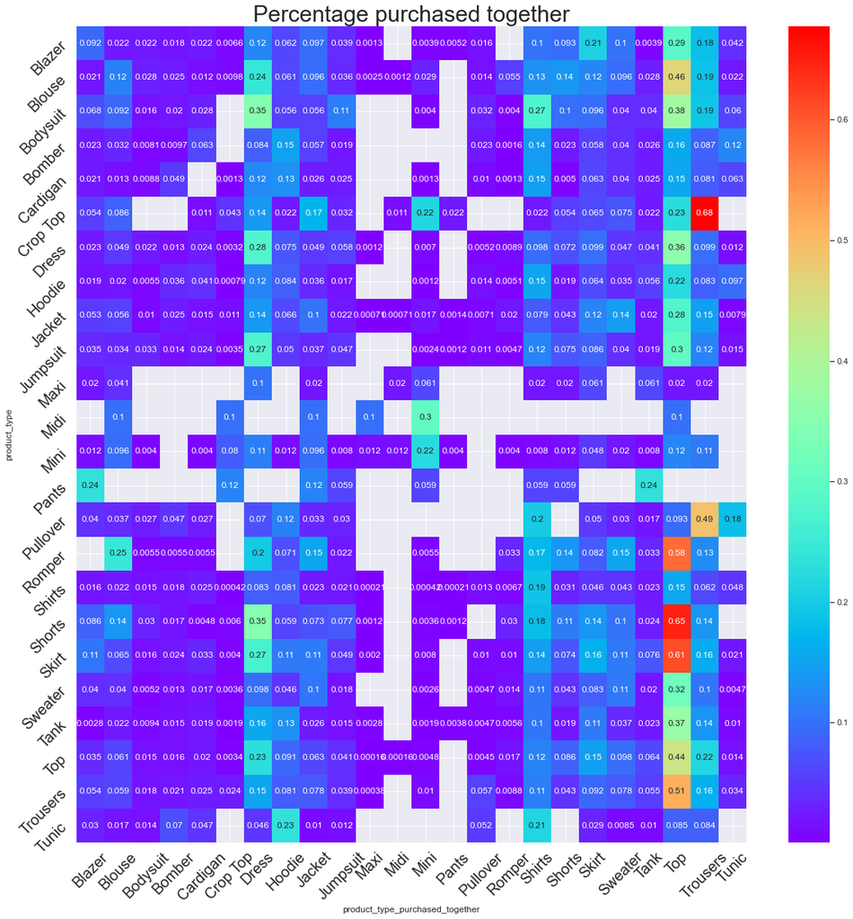

```python
fig, ax = plt.subplots(figsize=(20,20))
ax = sns.heatmap(hm_df,annot=True, cmap='rainbow')
ax.set_title('Percentage purchased together',fontsize=30)
plt.xticks(size=20,rotation=45)
plt.yticks(size=20,rotation=45)
plt.show()
```

The value in the heatmap is percentage that purchased each product type together instand of correlation. The result shows from the heatmap, most of the percentages are ver small. But there are still few of them around or bigger than 50%

# Part6: Sales and discount

## 1) How’s the sales of different products with discount?

```python
df_q3_1 = df_q2[df_q2['total_discounts'] != 0][['product_type', 'order_item_sale', 'quantity']].groupby('product_type').agg('sum')
df_q3_1 = df_q3_1.rename(columns={'order_item_sale': 'sales_with_discount', 'quantity': 'quantity_with_discount'})
df_q3_1.head()
```

| product_type | sales_with_discount | quantity_with_discount |
| --- | --- | --- |
| Blazer | 18321.70 | 266 |
| Blouse | 12704.40 | 326 |
| Bodysuit | 2418.40 | 70 |
| Bomber | 9032.79 | 179 |
| Cardigan | 9140.36 | 203 |

```python
df_q3_2 = df_q2[df_q2['total_discounts'] == 0][['product_type', 'order_item_sale', 'quantity']].groupby('product_type').agg('sum')
df_q3_2 = df_q3_2.rename(columns={'order_item_sale': 'sales_without_discount', 'quantity': 'quantity_without_discount'})
df_q3_2.head()
```

| product_type | sales_without_discount | quantity_without_discount |
| --- | --- | --- |
| Blazer | 34830.70 | 510 |
| Blouse | 22828.00 | 519 |
| Bodysuit | 6125.60 | 185 |
| Bomber | 30755.47 | 449 |
| Cardigan | 37532.40 | 602 |

```python
df_q3_3 = pd.merge(df_q3_1, df_q3_2, on='product_type' )
df_q3_3.head()
```

| product_type | sales_with_discount | quantity_with_discount | sales_without_discount | quantity_without_discount |
| --- | --- | --- | --- | --- |
| Blazer | 18321.70 | 266 | 34830.70 | 510 |
| Blouse | 12704.40 | 326 | 22828.00 | 519 |
| Bodysuit | 2418.40 | 70 | 6125.60 | 185 |
| Bomber | 9032.79 | 179 | 30755.47 | 449 |
| Cardigan | 9140.36 | 203 | 37532.40 | 602 |

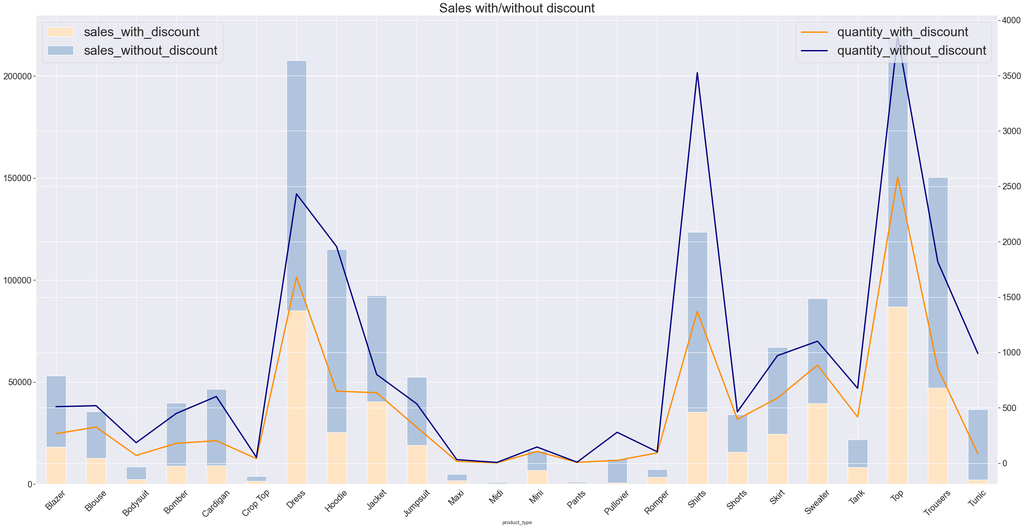

```python
fig, ax1 = plt.subplots(figsize=(40,20))
ax1 = df_q3_3[['sales_with_discount','sales_without_discount']].plot(ax=ax1, kind='bar',stacked=True,color=['bisque','lightsteelblue'])
ax1.set_title('Sales with/without discount',fontsize=30)
plt.xticks(size=20,rotation=45)
plt.yticks(size=20)
plt.legend(fontsize=30, loc ="upper left")

ax2 = ax1.twinx()
ax2 = df_q3_3[['quantity_with_discount','quantity_without_discount']].plot(ax=ax2,linewidth=3,color=['darkorange','navy'])
plt.xticks(size=20)
plt.yticks(size=20)
plt.legend(fontsize=30, loc ="upper right")
plt.show()
```

## 2) Does the discount promote sales?

```python
order_quantity = orders_items[['order_id','quantity']].groupby('order_id').agg('sum').reset_index(level='order_id')
order_quantity.head()
```

|  | order_id | quantity |
| --- | --- | --- |
| 0 | 7675398239 | 1 |
| 1 | 7676331935 | 2 |
| 2 | 7676363167 | 2 |
| 3 | 7676539359 | 4 |
| 4 | 7676549855 | 2 |

```python
df_q3_4=pd.merge(orders,order_quantity,how='left', on='order_id')
df_q3_4['discount_percentage']=df_q3_4['total_discounts']/df_q3_4['total_line_items_price']
df_q3_4['discount_orders']=(orders.total_discounts!=0)*1
df_q3_4['no_discount_orders']=(orders.total_discounts==0)*1
df_q3_4['total_orders']=1
df_q3_4['discount_quantity']=(orders.total_discounts!=0)*df_q3_4['quantity']
df_q3_4['no_discount_quantity']=(orders.total_discounts==0)*df_q3_4['quantity']
df_q3_4.info()
df_q3_4.head()
```

```
<class 'pandas.core.frame.DataFrame'>
Int64Index: 21003 entries, 0 to 21002
Data columns (total 20 columns):
 #   Column                  Non-Null Count  Dtype
---  ------                  --------------  -----
 0   order_id                21003 non-null  object
 1   order_created_at        21003 non-null  datetime64[ns]
 2   order_closed_at         19869 non-null  object
 3   cancelled_at            409 non-null    object
 4   customer_id             21003 non-null  object
 5   financial_status        21003 non-null  object
 6   fulfillment_status      20346 non-null  object
 7   processed_at            21003 non-null  object
 8   total_price             21003 non-null  float64
 9   shipping_rate           21003 non-null  float64
 10  subtotal_price          21003 non-null  float64
 11  total_discounts         21003 non-null  float64
 12  total_line_items_price  21003 non-null  float64
 13  quantity                21003 non-null  int64
 14  discount_percentage     21000 non-null  float64
 15  discount_orders         20669 non-null  float64
 16  no_discount_orders      20669 non-null  float64
 17  total_orders            21003 non-null  int64
 18  discount_quantity       20669 non-null  object
 19  no_discount_quantity    20669 non-null  object
dtypes: datetime64[ns](1), float64(8), int64(2), object(9)
memory usage: 3.9+ MB
```

|  | order_id | order_created_at | order_closed_at | cancelled_at | customer_id | financial_status | fulfillment_status | processed_at | total_price | shipping_rate | subtotal_price | total_discounts | total_line_items_price | quantity | discount_percentage | discount_orders | no_discount_orders | total_orders | discount_quantity | no_discount_quantity |
| --- | --- | --- | --- | --- | --- | --- | --- | --- | --- | --- | --- | --- | --- | --- | --- | --- | --- | --- | --- | --- |
| 0 | 7675398239 | 2016-08-21 | 2016-08-25 | 2016-08-22 | 8683754719 | voided | NaN | 2016-08-21 | 44.57 | 6.33 | 35.0 | 0.0 | 35.0 | 1 | 0.0 | 0.0 | 1.0 | 1 | 0.0 | 1.0 |
| 1 | 7676331935 | 2016-08-22 | 2016-08-22 | NaN | 8686224991 | refunded | NaN | 2016-08-22 | 124.55 | 0.00 | 114.0 | 0.0 | 114.0 | 2 | 0.0 | 0.0 | 1.0 | 1 | 0.0 | 2.0 |
| 2 | 7676363167 | 2016-08-22 | NaN | 2016-08-22 | 8686224991 | voided | NaN | 2016-08-22 | 97.68 | 7.00 | 83.0 | 0.0 | 83.0 | 2 | 0.0 | 0.0 | 1.0 | 1 | 0.0 | 2.0 |
| 3 | 7676539359 | 2016-08-22 | 2016-08-22 | NaN | 8686915935 | paid | fulfilled | 2016-08-22 | 131.10 | 0.00 | 120.0 | 0.0 | 120.0 | 4 | 0.0 | 0.0 | 1.0 | 1 | 0.0 | 4.0 |
| 4 | 7676549855 | 2016-08-22 | 2016-08-22 | NaN | 8686924319 | paid | fulfilled | 2016-08-22 | 91.12 | 7.00 | 77.0 | 0.0 | 77.0 | 2 | 0.0 | 0.0 | 1.0 | 1 | 0.0 | 2.0 |

```python
df_q3_4.discount_quantity = df_q3_4.discount_quantity.astype('float')
df_q3_4.no_discount_quantity = df_q3_4.no_discount_quantity.astype('float')
```

```python
df_q3_5 = df_q3_4.groupby('order_created_at')['discount_quantity','no_discount_quantity','discount_orders','no_discount_orders','total_orders','discount_percentage'].sum()
df_q3_5.head()
```

| order_created_at | discount_quantity | no_discount_quantity | discount_orders | no_discount_orders | total_orders | discount_percentage |
| --- | --- | --- | --- | --- | --- | --- |
| 2016-08-21 | 0.0 | 1.0 | 0.0 | 1.0 | 1 | 0.0 |
| 2016-08-22 | 4.0 | 1432.0 | 3.0 | 790.0 | 794 | 1.0 |
| 2016-08-23 | 4.0 | 279.0 | 2.0 | 181.0 | 183 | 0.0 |
| 2016-08-24 | 0.0 | 73.0 | 0.0 | 44.0 | 44 | 0.0 |
| 2016-08-25 | 3.0 | 80.0 | 3.0 | 59.0 | 62 | 0.0 |

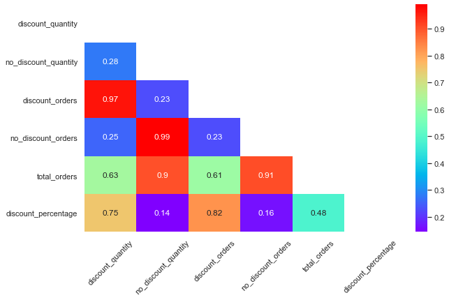

```python
plt.figure(figsize=(10,6))
mask = np.zeros_like(df_q3_5.corr())
mask[np.triu_indices_from(mask)] = True
with sns.axes_style('white'):
    sns.heatmap(df_q3_5.corr(), annot=True, cmap='rainbow', mask=mask)
plt.xticks(rotation=45)
plt.show()
```

The correlation heatmap shows that discount promote sales. Because discount_percentage has positive correlation coefficient with discount_quantity(0.75) and discount_orders(0.82). The correlation of discount_orders and total_orders is only 0.61, and the correlation of no_discount_orders and total_orders is 0.91, which means no_discount_orders has more influential for the total orders because no_discount_orders is more common than discount_orders in reality.